# Size matters, so does condition: the use of a body condition index reveals the costs and benefits of structural body size in an insect.

Mark Gillingham

2023-03-29

## Load packages

```r
library(rptR)
library(smatr)
library(dplyr)
library(MASS)
library(MuMIn)
library(boot)
library(ggplot2)
library(car)
library(grid)
library(gtable)
library(gridExtra)
library(ggpubr)
library(grid)
library(multcomp)
library(finalfit)
library(lmodel2)
```

## Load source files

```r
setwd("~/Dropbox/condition/ANALYSE/FinalAnalysis")
Rep = read.table(file = "Repetability.txt", header = TRUE)
Rep <- Rep[which(Rep$FecondIncomplet == 0), ]
names(Rep)
INDICES = read.csv(file = "CALCULINDICES.csv",
    header = TRUE)
INDICES <- INDICES[which(INDICES$FecondIncomplet ==
    0), ]
names(INDICES)
head(INDICES)
dosages = read.csv(file = "DOSAGES.csv", header = TRUE)
names(dosages)
Fecond = read.csv(file = "FeconditePropreNew.csv",
    header = TRUE)
Fecond <- Fecond[which(!Fecond$Days.laid == "NA" &
    !Fecond$Mort == 1), ]
names(Fecond)
```

## Validation of structural size and body condition indexes as measure of absolute and relative energy reserves respectively

We first set out to validate whether morphometric measures and BCIs were reliable indicators of energy reserves. To that effect, we first tested the repeatability of the morphometric measure elytron length using the R package “rptR” and the strength of its correlation with mass (Stoffel and Nakagawa, 2017), both important preconditions of valid BCIs using these metrics (Peig and Green 2009; 2010).

```r
rpt(longueur ~ (1 | individus), data = Rep, grname = "individus",
    nboot = 10000, datatype = "Gaussian")
```

```
## Bootstrap Progress:
```

```
##
##
## Repeatability estimation using the lmm method
##
## Repeatability for individus
## R  = 0.921
## SE = 0.009
## CI = [0.902, 0.936]
## P  = 1.93e-134 [LRT]
##      NA [Permutation]
```

```r
cor.test(log10(INDICES$moylargeur), log10(INDICES$moyLong))
```

```
##
##  Pearson's product-moment correlation
##
## data:  log10(INDICES$moylargeur) and log10(INDICES$moyLong)
## t = 22.209, df = 325, p-value < 2.2e-16
## alternative hypothesis: true correlation is not equal to 0
## 95 percent confidence interval:
##  0.7293690 0.8161415
## sample estimates:
##       cor
## 0.7764087
```

```r
png("/home/mark/Dropbox/condition/apres JEB/loglargeurLongueur.png",
    width = 2100, height = 2970, res = 300)
plot(log(INDICES$moyLong) ~ log(INDICES$poids),
    ylab = "log (mass (g))", xlab = "log (elytron length (mm))")
dev.off()
```

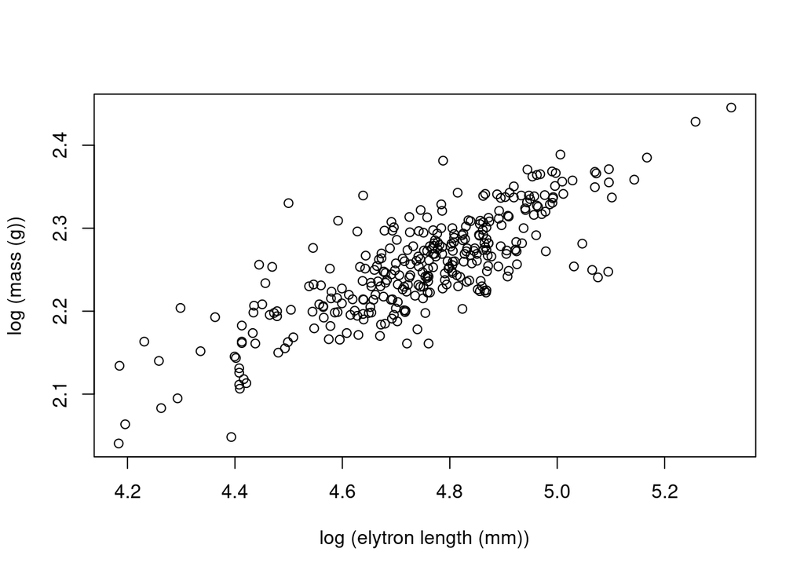

```r
plot(log(INDICES$moyLong) ~ log(INDICES$poids),
    ylab = "log (mass (g))", xlab = "log (elytron length (mm))")
```

Second, we investigated Pearson correlations between measures of energy reserves and morphometric measures as well as with BCIs. We also performed partial correlation between mass and each measure of energy reserve controlling for elytron length. Prior to correlations all morphometric measures and energetic reserves were log transformed.

We calculate BCIs:

```r
M1 <- lm(log(poids) ~ log(moyLong), data = INDICES)
summary(M1)
```

```
##
## Call:
## lm(formula = log(poids) ~ log(moyLong), data = INDICES)
##
## Residuals:
##      Min       1Q   Median       3Q      Max
## -0.42744 -0.05415  0.00378  0.06293  0.36466
##
## Coefficients:
##              Estimate Std. Error t value Pr(>|t|)
## (Intercept)  -0.62855    0.21938  -2.865  0.00444 **
## log(moyLong)  2.38426    0.09724  24.520  < 2e-16 ***
## ---
## Signif. codes:  0 '***' 0.001 '**' 0.01 '*' 0.05 '.' 0.1 ' ' 1
##
## Residual standard error: 0.1103 on 325 degrees of freedom
## Multiple R-squared:  0.6491, Adjusted R-squared:  0.648
## F-statistic: 601.2 on 1 and 325 DF,  p-value: < 2.2e-16
```

```r
INDICES$OLS <- residuals(M1)
M2 <- sma(poids ~ moyLong, log = "xy", data = INDICES)
print(M2)
```

```
## Call: sma(formula = poids ~ moyLong, data = INDICES, log = "xy")
##
## Fit using Standardized Major Axis
##
## These variables were log-transformed before fitting: xy
##
## Confidence intervals (CI) are at 95%
##
## ------------------------------------------------------------
## Coefficients:
##              elevation    slope
## estimate    -0.8362235 2.959333
## lower limit -1.0236654 2.774214
## upper limit -0.6487816 3.156805
##
## H0 : variables uncorrelated
## R-squared : 0.649112
## P-value : < 2.22e-16
```

```r
INDICES$SMI <- INDICES$poids * ((mean(INDICES$moyLong)/INDICES$moyLong)^M2$groupsummary$Slope)

BCIs <- data.frame(individu = INDICES$individu,
    OLS = INDICES$OLS, SMI = INDICES$SMI)

dosages <- (left_join(dosages, BCIs, by = "individu"))
```

As there was a strong correlation between circulating sugars and glycogen in the beetles, we considered both compounds together in the results.

```r
cor.test(log(dosages$glucose), log(dosages$glycogen),
    method = "pearson")
```

```
##
##  Pearson's product-moment correlation
##
## data:  log(dosages$glucose) and log(dosages$glycogen)
## t = 12.911, df = 87, p-value < 2.2e-16
## alternative hypothesis: true correlation is not equal to 0
## 95 percent confidence interval:
##  0.7246878 0.8717069
## sample estimates:
##       cor
## 0.8106068
```

```r
png("/home/mark/Dropbox/condition/apres JEB/GlucoseGlycogen.png",
    width = 2100, height = 2100, res = 300)
dev.off()
```

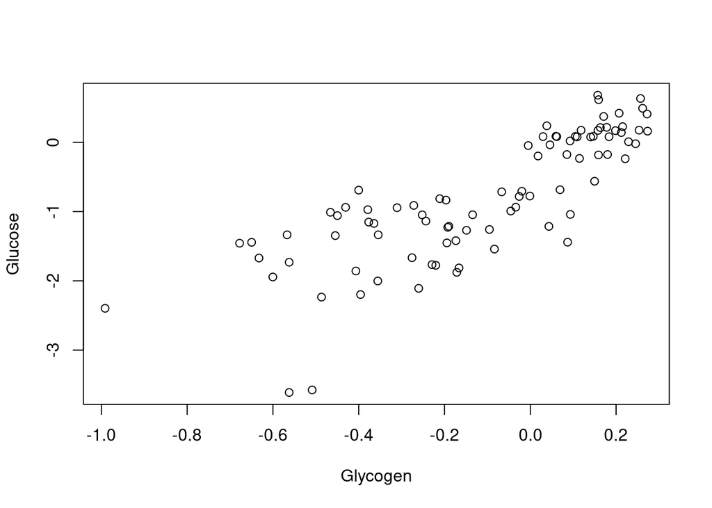

```r
plot(log(dosages$glucose) ~ log10(dosages$glycogen),
    ylab = "Glucose", xlab = "Glycogen")
```

```r
M3 <- sma(lipides ~ moyLong, log = "xy", data = dosages)
print(M3)
dosages$SLipides <- dosages$lipides * ((mean(dosages$moyLong)/dosages$moyLong)^M3$groupsummary$Slope)
M4 <- sma(sumLGly ~ moyLong, log = "xy", data = dosages)
print(M4)
dosages$SsumLGly <- dosages$sumLGly * ((mean(dosages$moyLong)/dosages$moyLong)^M4$groupsummary$Slope)
```

We estimate correlations between measures of energy reserves and morphometric measures as well as with BCIs:

```r
cor.test(log(dosages$moyLong), log(dosages$lipides),
    method = "pearson")
```

```
##
##  Pearson's product-moment correlation
##
## data:  log(dosages$moyLong) and log(dosages$lipides)
## t = 7.2108, df = 87, p-value = 1.928e-10
## alternative hypothesis: true correlation is not equal to 0
## 95 percent confidence interval:
##  0.4622429 0.7272460
## sample estimates:
##       cor
## 0.6116218
```

```r
cor.test(log(dosages$moyLong), log(dosages$sumLGly),
    method = "pearson")
```

```
##
##  Pearson's product-moment correlation
##
## data:  log(dosages$moyLong) and log(dosages$sumLGly)
## t = 9.224, df = 87, p-value = 1.561e-14
## alternative hypothesis: true correlation is not equal to 0
## 95 percent confidence interval:
##  0.5798050 0.7949965
## sample estimates:
##       cor
## 0.7031568
```

```r
cor.test(log(dosages$poids), log(dosages$lipides),
    method = "pearson")
```

```
##
##  Pearson's product-moment correlation
##
## data:  log(dosages$poids) and log(dosages$lipides)
## t = 8.7625, df = 87, p-value = 1.376e-13
## alternative hypothesis: true correlation is not equal to 0
## 95 percent confidence interval:
##  0.5556683 0.7815112
## sample estimates:
##       cor
## 0.6846914
```

```r
cor.test(log(dosages$poids), log(dosages$sumLGly),
    method = "pearson")
```

```
##
##  Pearson's product-moment correlation
##
## data:  log(dosages$poids) and log(dosages$sumLGly)
## t = 10.256, df = 87, p-value < 2.2e-16
## alternative hypothesis: true correlation is not equal to 0
## 95 percent confidence interval:
##  0.6283384 0.8214834
## sample estimates:
##       cor
## 0.7397895
```

```r
cor.test(log(dosages$poids), log(dosages$SLipides),
    method = "pearson")
```

```
##
##  Pearson's product-moment correlation
##
## data:  log(dosages$poids) and log(dosages$SLipides)
## t = -1.355, df = 87, p-value = 0.1789
## alternative hypothesis: true correlation is not equal to 0
## 95 percent confidence interval:
##  -0.34178360  0.06648782
## sample estimates:
##        cor
## -0.1437595
```

```r
cor.test(log(dosages$poids), log(dosages$SsumLGly),
    method = "pearson")
```

```
##
##  Pearson's product-moment correlation
##
## data:  log(dosages$poids) and log(dosages$SsumLGly)
## t = -0.87055, df = 87, p-value = 0.3864
## alternative hypothesis: true correlation is not equal to 0
## 95 percent confidence interval:
##  -0.2954673  0.1176040
## sample estimates:
##         cor
## -0.09292875
```

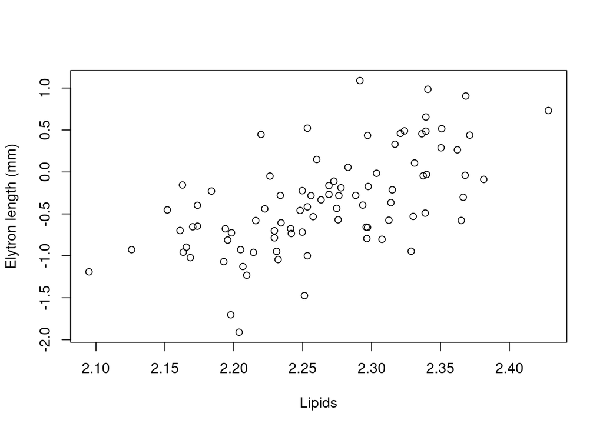

```r
# par(mfrow=c(3,2))
plot(log(dosages$moyLong), log(dosages$lipides),
    ylab = "Elytron length (mm)", xlab = "Lipids")
```

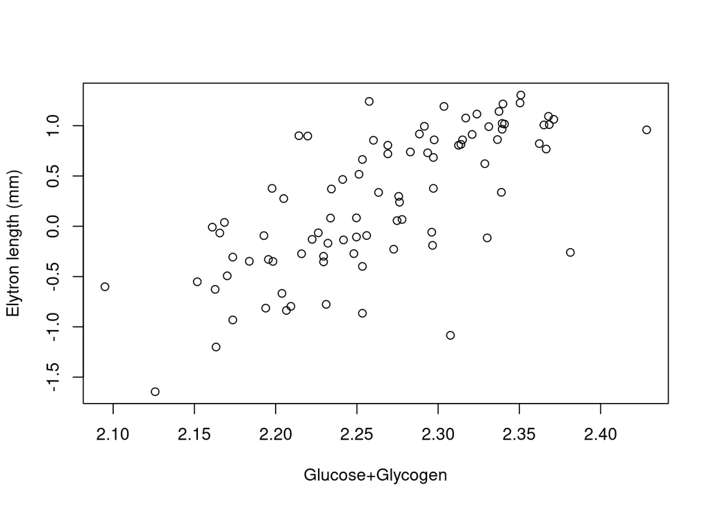

```r
plot(log(dosages$moyLong), log(dosages$sumLGly),
    ylab = "Elytron length (mm)", xlab = "Glucose+Glycogen")
```

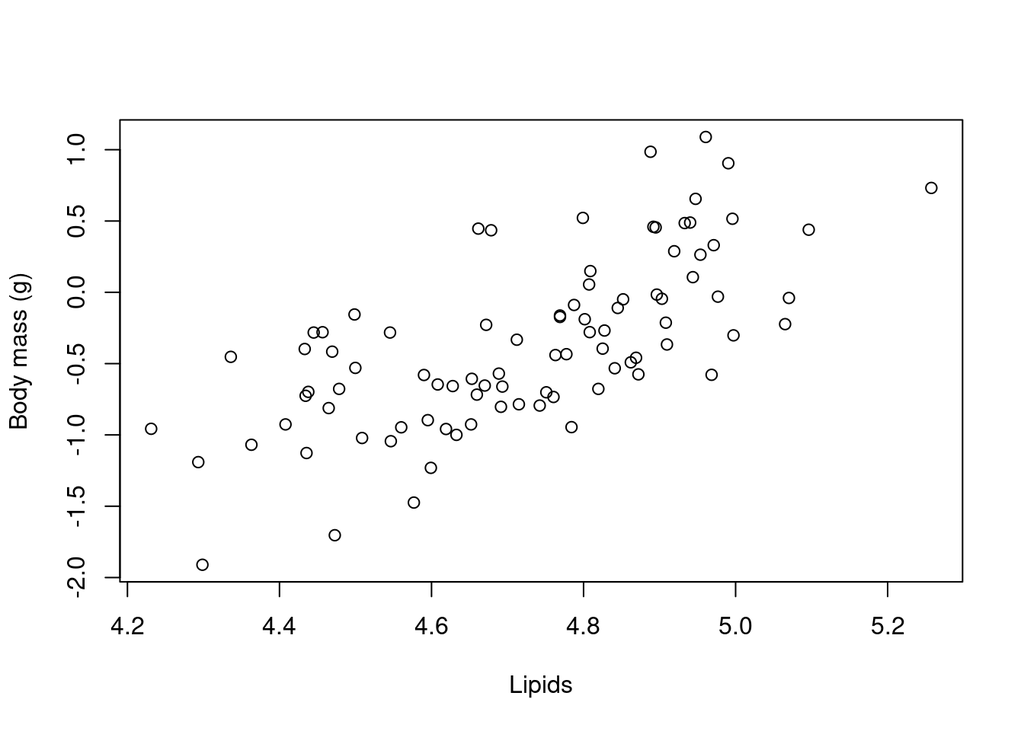

```r
plot(log(dosages$poids), log(dosages$lipides),
    ylab = "Body mass (g)", xlab = "Lipids")
```

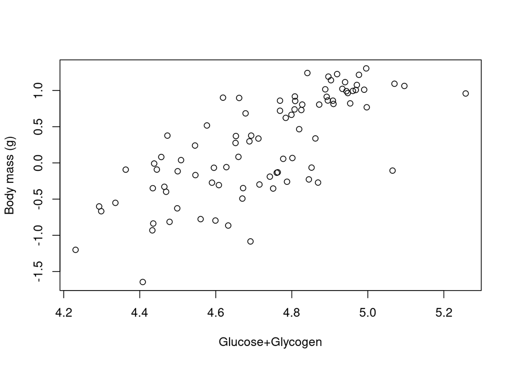

```r
plot(log(dosages$poids), log(dosages$sumLGly),
    ylab = "Body mass (g)", xlab = "Glucose+Glycogen")
```

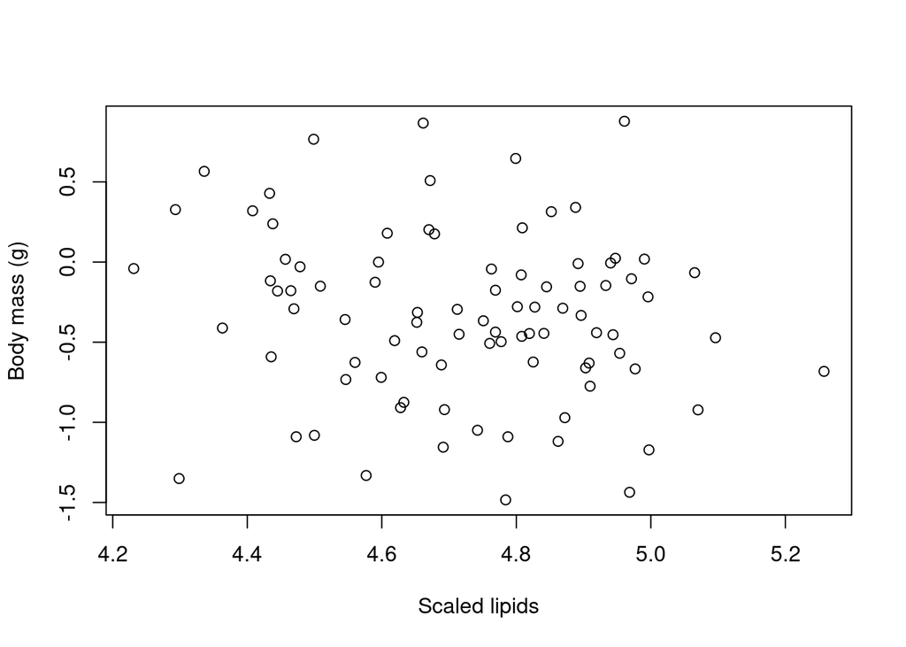

```r
plot(log(dosages$poids), log(dosages$SLipides),
    ylab = "Body mass (g)", xlab = "Scaled lipids")
```

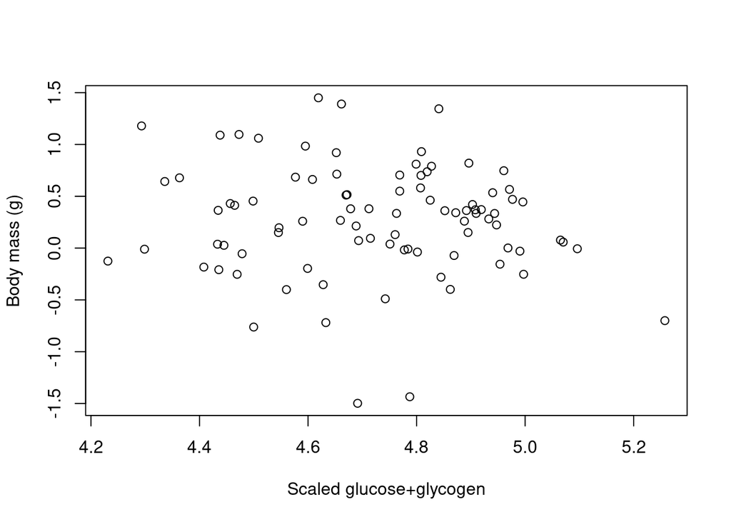

```r
plot(log(dosages$poids), log(dosages$SsumLGly),
    ylab = "Body mass (g)", xlab = "Scaled glucose+glycogen")
```

```r
cor.test(dosages$OLS, log(dosages$lipides), method = "pearson")
```

```
##
##  Pearson's product-moment correlation
##
## data:  dosages$OLS and log(dosages$lipides)
## t = 3.7662, df = 87, p-value = 0.0003008
## alternative hypothesis: true correlation is not equal to 0
## 95 percent confidence interval:
##  0.1802033 0.5405197
## sample estimates:
##      cor
## 0.374409
```

```r
cor.test(dosages$OLS, log(dosages$sumLGly), method = "pearson")
```

```
##
##  Pearson's product-moment correlation
##
## data:  dosages$OLS and log(dosages$sumLGly)
## t = 3.4816, df = 87, p-value = 0.0007817
## alternative hypothesis: true correlation is not equal to 0
## 95 percent confidence interval:
##  0.1525569 0.5200833
## sample estimates:
##       cor
## 0.3497033
```

```r
cor.test(dosages$OLS, log(dosages$SLipides), method = "pearson")
```

```
##
##  Pearson's product-moment correlation
##
## data:  dosages$OLS and log(dosages$SLipides)
## t = 3.2165, df = 87, p-value = 0.001823
## alternative hypothesis: true correlation is not equal to 0
## 95 percent confidence interval:
##  0.1263289 0.5002985
## sample estimates:
##       cor
## 0.3260088
```

```r
cor.test(dosages$OLS, log(dosages$SsumLGly), method = "pearson")
```

```
##
##  Pearson's product-moment correlation
##
## data:  dosages$OLS and log(dosages$SsumLGly)
## t = 3.3816, df = 87, p-value = 0.001081
## alternative hypothesis: true correlation is not equal to 0
## 95 percent confidence interval:
##  0.1427095 0.5127010
## sample estimates:
##       cor
## 0.3408365
```

```r
cor.test(dosages$SMI, log(dosages$lipides), method = "pearson")
```

```
##
##  Pearson's product-moment correlation
##
## data:  dosages$SMI and log(dosages$lipides)
## t = 1.5986, df = 87, p-value = 0.1135
## alternative hypothesis: true correlation is not equal to 0
## 95 percent confidence interval:
##  -0.04076309  0.36436592
## sample estimates:
##       cor
## 0.1689277
```

```r
cor.test(dosages$SMI, log(dosages$sumLGly), method = "pearson")
```

```
##
##  Pearson's product-moment correlation
##
## data:  dosages$SMI and log(dosages$sumLGly)
## t = 0.91001, df = 87, p-value = 0.3653
## alternative hypothesis: true correlation is not equal to 0
## 95 percent confidence interval:
##  -0.1134486  0.2993065
## sample estimates:
##        cor
## 0.09710236
```

```r
cor.test(dosages$SMI, log(dosages$SLipides), method = "pearson")
```

```
##
##  Pearson's product-moment correlation
##
## data:  dosages$SMI and log(dosages$SLipides)
## t = 4.7254, df = 87, p-value = 8.76e-06
## alternative hypothesis: true correlation is not equal to 0
## 95 percent confidence interval:
##  0.2689923 0.6033982
## sample estimates:
##       cor
## 0.4519321
```

```r
cor.test(dosages$SMI, log(dosages$SsumLGly), method = "pearson")
```

```
##
##  Pearson's product-moment correlation
##
## data:  dosages$SMI and log(dosages$SsumLGly)
## t = 4.3632, df = 87, p-value = 3.511e-05
## alternative hypothesis: true correlation is not equal to 0
## 95 percent confidence interval:
##  0.2363146 0.5807303
## sample estimates:
##       cor
## 0.4237184
```

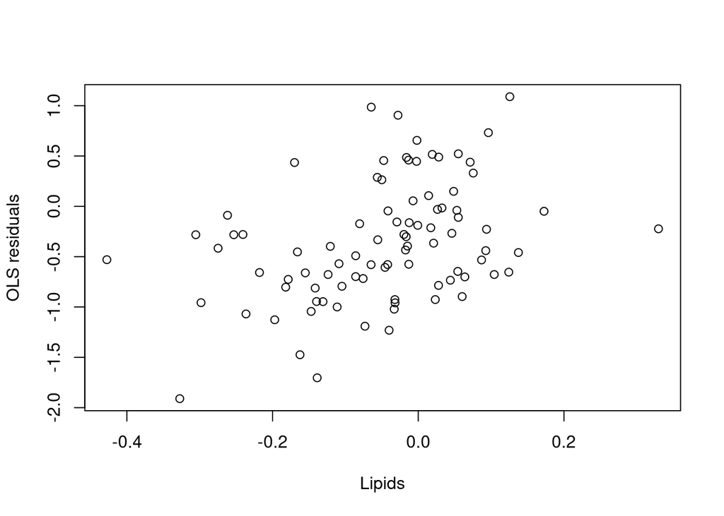

```r
# par(mfrow=c(4,2))
plot(dosages$OLS, log(dosages$lipides), ylab = "OLS residuals",
    xlab = "Lipids")
```

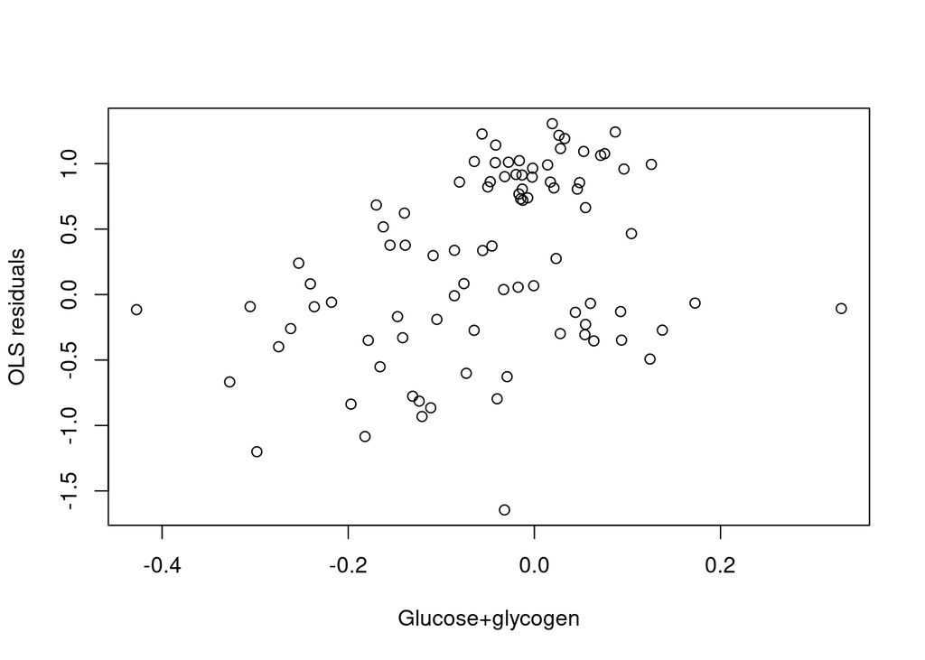

```r
plot(dosages$OLS, log(dosages$sumLGly), ylab = "OLS residuals",
    xlab = "Glucose+glycogen")
```

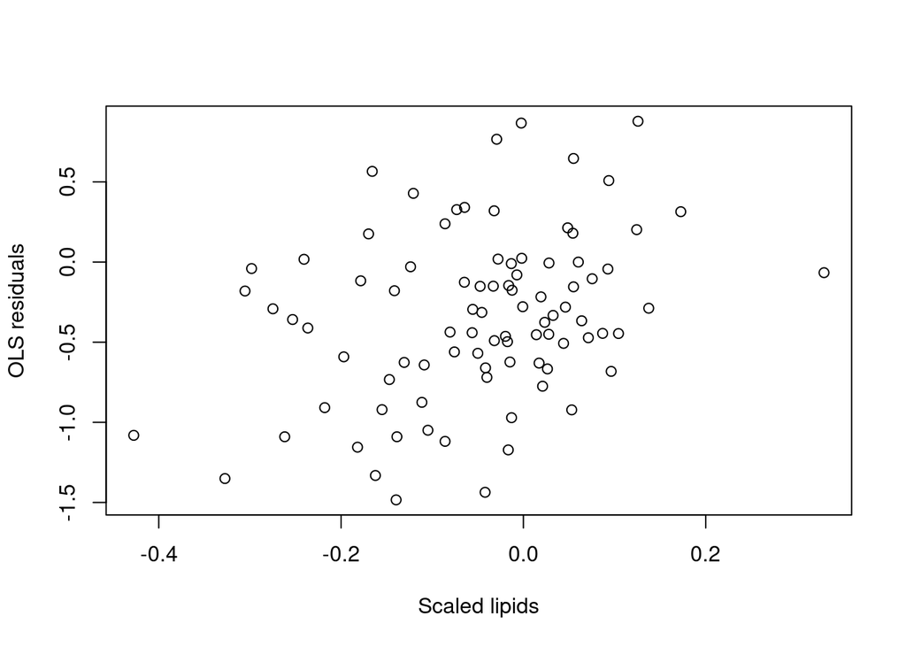

```r
plot(dosages$OLS, log(dosages$SLipides), ylab = "OLS residuals",
    xlab = "Scaled lipids")
```

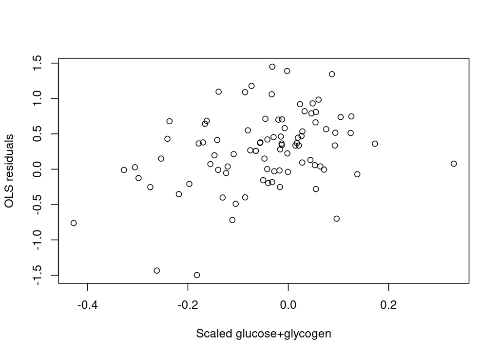

```r
plot(dosages$OLS, log(dosages$SsumLGly), ylab = "OLS residuals",
    xlab = "Scaled glucose+glycogen")
```

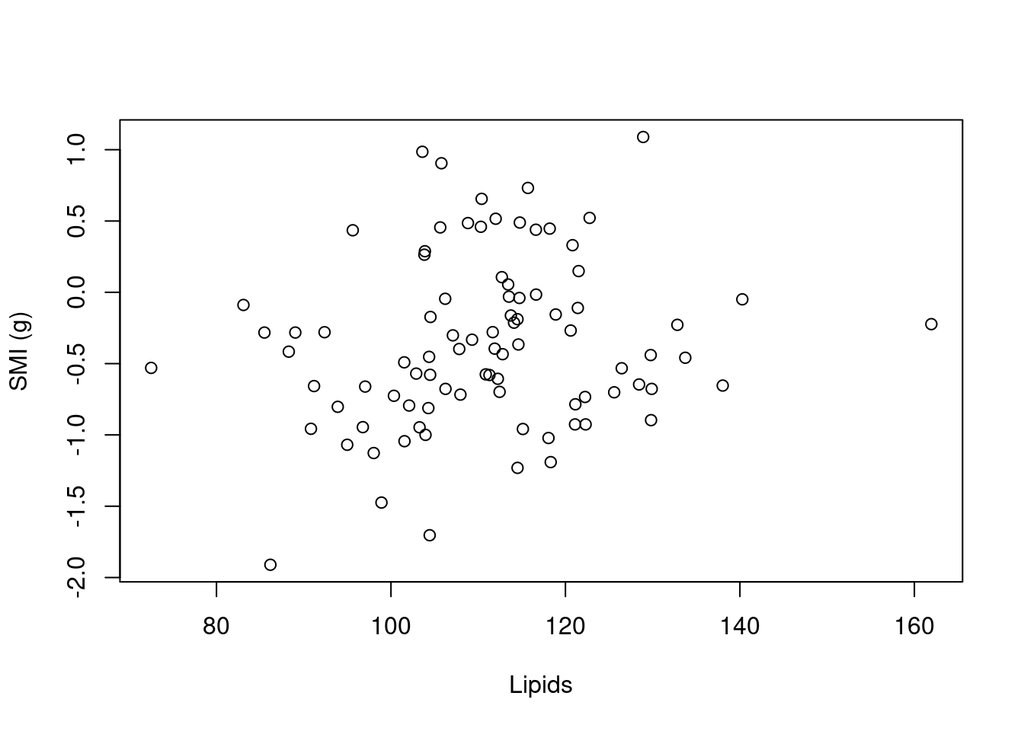

```r
plot(dosages$SMI, log(dosages$lipides), ylab = "SMI (g)",
    xlab = "Lipids")
```

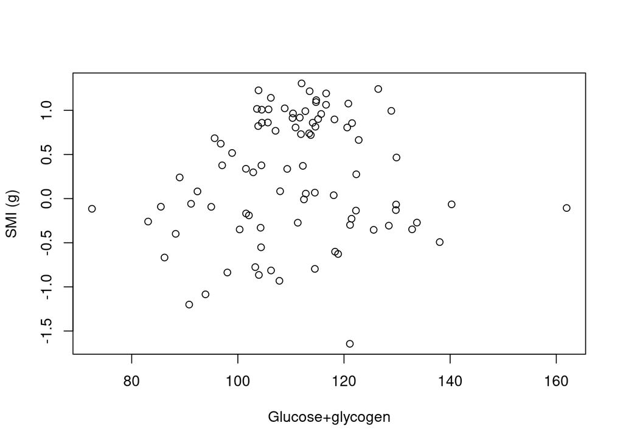

```r
plot(dosages$SMI, log(dosages$sumLGly), ylab = "SMI (g)",
    xlab = "Glucose+glycogen")
```

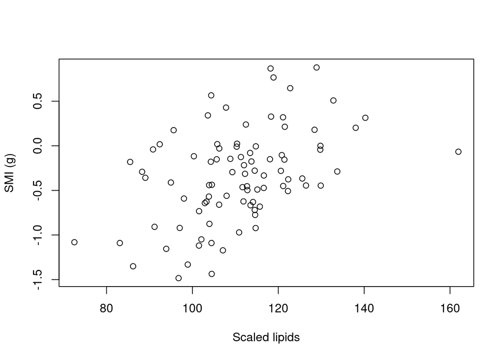

```r
plot(dosages$SMI, log(dosages$SLipides), ylab = "SMI (g)",
    xlab = "Scaled lipids")
```

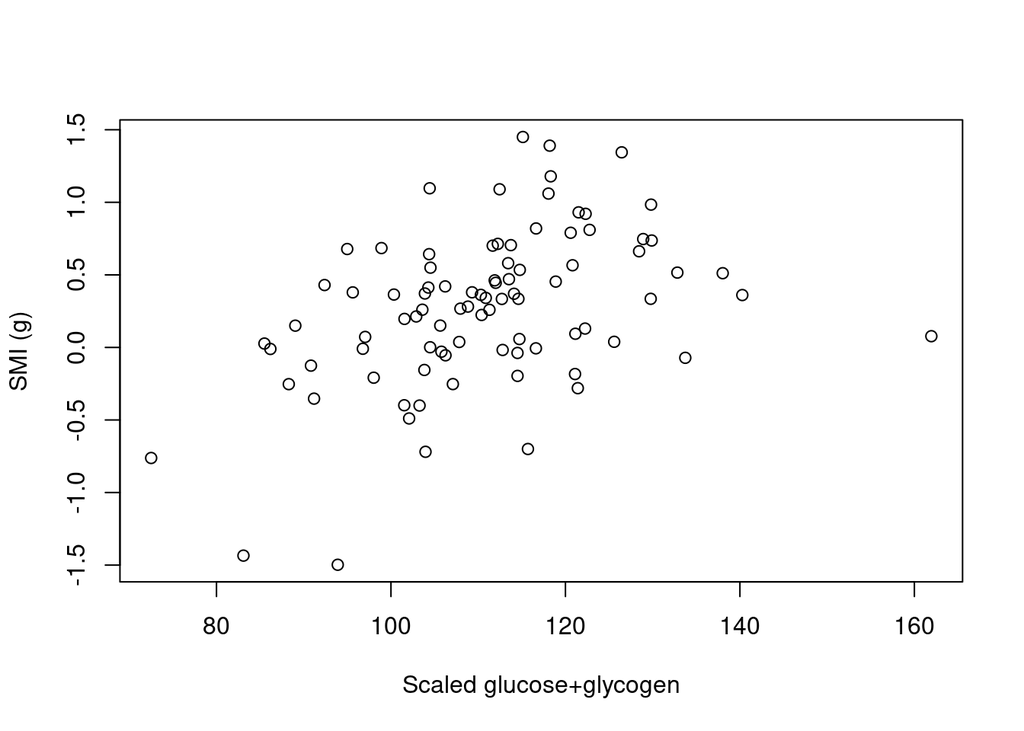

```r
plot(dosages$SMI, log(dosages$SsumLGly), ylab = "SMI (g)",
    xlab = "Scaled glucose+glycogen")
```

## The relevance of structural size and body condition as predictors of fitness in an insect model

```r
Fecond$TreatAdult <- factor(Fecond$TreatAdult,
    c("PN", "N"))
Fecond$TreatAdult
```

```
##   [1] PN PN PN PN N  N  N  N  N  N  N  N  N  N  N  N  N  N  N  N  N  N  PN PN PN
##  [26] PN PN PN PN PN PN PN PN PN PN PN PN PN PN PN PN PN PN PN PN PN PN PN PN PN
##  [51] PN PN PN PN PN PN PN N  N  N  N  N  N  N  N  N  N  N  N  N  N  N  N  N  N
##  [76] N  N  N  N  N  N  N  N  N  N  N  N  N  N  N  N  N  N  N  N  PN PN PN PN PN
## [101] PN PN PN PN PN PN PN PN PN PN N  N  N  PN PN PN N  N  N  PN N  PN N  PN N
## [126] PN PN PN PN PN PN PN PN PN PN PN N  N  N  N  N  N  N  PN PN PN PN PN PN N
## [151] N  N  PN PN PN PN N  N  N  N  N  N  N  PN PN PN PN PN PN N  N  N  PN PN PN
## [176] PN PN N  N  N  PN PN PN N  N  N  N  N  PN PN PN PN PN PN PN PN PN PN PN PN
## [201] N  N  N  N  N  N  N  N  N  N  N  N  N  PN PN PN N  N  N  N  N
## Levels: PN N
```

```r
MNull <- glm.nb(eggs ~ 1, na.action = na.fail,
    data = Fecond)
M5 <- glm.nb(eggs ~ MSL, na.action = na.fail,
    data = Fecond)
M6 <- glm.nb(eggs ~ poids, na.action = na.fail,
    data = Fecond)
M7 <- glm.nb(eggs ~ moyLong, na.action = na.fail,
    data = Fecond)
M8 <- glm.nb(eggs ~ poids + moyLong, na.action = na.fail,
    data = Fecond)
M9 <- glm.nb(eggs ~ MSL + moyLong, na.action = na.fail,
    data = Fecond)

cor.test(Fecond$moyLong, Fecond$poids)
```

```
##
##  Pearson's product-moment correlation
##
## data:  Fecond$moyLong and Fecond$poids
## t = 20.395, df = 219, p-value < 2.2e-16
## alternative hypothesis: true correlation is not equal to 0
## 95 percent confidence interval:
##  0.7584145 0.8505016
## sample estimates:
##       cor
## 0.8093762
```

```r
vif(M8)
```

```
##    poids  moyLong
## 2.898225 2.898225
```

```r
ModelSel <- model.sel(MNull, M5, M6, M7, M8, M9,
    rank = AICc)
R2 <- c(r.squaredLR(M9), r.squaredLR(M8), r.squaredLR(M6),
    r.squaredLR(M5), r.squaredLR(MNull), r.squaredLR(M7))
ModelSel$R2 <- R2
ModelSel
```

```
## Model selection table
##       (Intrc)      MSL    poids    myLng       family init.theta df    logLik
## M9      1.809 0.009882           0.15290 NB(3.7593,l)       3.76  4 -1133.662
## M8      5.164          0.009579 -0.19490 NB(3.7438,l)       3.74  4 -1134.115
## M6      3.825          0.005228          NB(3.6889,l)       3.69  3 -1135.732
## M5      3.525 0.007728                   NB(3.6738,l)       3.67  3 -1136.192
## MNull   4.449                            NB(3.5537,l)       3.55  2 -1139.856
## M7      3.676                    0.08107 NB(3.5779,l)       3.58  3 -1139.106
##         AICc delta weight        R2
## M9    2275.5  0.00  0.446 5.451e-02
## M8    2276.4  0.91  0.283 5.063e-02
## M6    2277.6  2.07  0.159 3.663e-02
## M5    2278.5  2.99  0.100 3.261e-02
## MNull 2283.8  8.26  0.007 1.625e-13
## M7    2284.3  8.81  0.005 6.765e-03
## Abbreviations:
##  family: NB(3.5537,l) = 'Negative Binomial(3.5537,log)',
##          NB(3.5779,l) = 'Negative Binomial(3.5779,log)',
##          NB(3.6738,l) = 'Negative Binomial(3.6738,log)',
##          NB(3.6889,l) = 'Negative Binomial(3.6889,log)',
##          NB(3.7438,l) = 'Negative Binomial(3.7438,log)',
##          NB(3.7593,l) = 'Negative Binomial(3.7593,log)'
## Models ranked by AICc(x)
```

```r
write.table(ModelSel, "/home/mark/Dropbox/condition/ANALYSE/FinalAnalysis/ModelSel6models.txt")


partial.r <- function(t.val, df) {
    r <- t.val/sqrt((t.val)^2 + df)
    names(r) <- "effect size r"
    return(r)
}

r.part <- function(formula, data, indices) {
    d <- data[indices, ]  # allows boot to select sample
    fit <- glm.nb(formula, data = d)
    return(partial.r(coef(summary(fit))[2, 3],
        218))
}

(results <- boot(data = Fecond, statistic = r.part,
    R = 10000, formula = eggs ~ poids))
```

```
##
## ORDINARY NONPARAMETRIC BOOTSTRAP
##
##
## Call:
## boot(data = Fecond, statistic = r.part, R = 10000, formula = eggs ~
##     poids)
##
##
## Bootstrap Statistics :
##     original        bias    std. error
## t1*  0.19736 -0.0001168857  0.06097795
```

```r
set.seed(1)
(Boot <- boot.ci(results, type = "bca"))
```

```
## BOOTSTRAP CONFIDENCE INTERVAL CALCULATIONS
## Based on 10000 bootstrap replicates
##
## CALL :
## boot.ci(boot.out = results, type = "bca")
##
## Intervals :
## Level       BCa
## 95%   ( 0.0674,  0.3092 )
## Calculations and Intervals on Original Scale
```

```r
Poids <- as.numeric(results$t0)
minci.Poids <- Boot$bca[, 4]
maxci.Poids <- Boot$bca[, 5]

(results <- boot(data = Fecond, statistic = r.part,
    R = 10000, formula = eggs ~ moyLong))
```

```
##
## ORDINARY NONPARAMETRIC BOOTSTRAP
##
##
## Call:
## boot(data = Fecond, statistic = r.part, R = 10000, formula = eggs ~
##     moyLong)
##
##
## Bootstrap Statistics :
##       original        bias    std. error
## t1* 0.08564932 -0.0005467156  0.06444605
```

```r
set.seed(1)
(Boot <- boot.ci(results, type = "bca"))
```

```
## BOOTSTRAP CONFIDENCE INTERVAL CALCULATIONS
## Based on 10000 bootstrap replicates
##
## CALL :
## boot.ci(boot.out = results, type = "bca")
##
## Intervals :
## Level       BCa
## 95%   (-0.0402,  0.2114 )
## Calculations and Intervals on Original Scale
```

```r
Long <- as.numeric(results$t0)
minci.Long <- Boot$bca[, 4]
maxci.Long <- Boot$bca[, 5]

(results <- boot(data = Fecond, statistic = r.part,
    R = 10000, formula = eggs ~ MSL))
```

```
##
## ORDINARY NONPARAMETRIC BOOTSTRAP
##
##
## Call:
## boot(data = Fecond, statistic = r.part, R = 10000, formula = eggs ~
##     MSL)
##
##
## Bootstrap Statistics :
##      original        bias    std. error
## t1* 0.1830902 -0.0002201626   0.0559724
```

```r
set.seed(1)
(Boot <- boot.ci(results, type = "bca"))
```

```
## BOOTSTRAP CONFIDENCE INTERVAL CALCULATIONS
## Based on 10000 bootstrap replicates
##
## CALL :
## boot.ci(boot.out = results, type = "bca")
##
## Intervals :
## Level       BCa
## 95%   ( 0.0708,  0.2888 )
## Calculations and Intervals on Original Scale
```

```r
msl <- as.numeric(results$t0)
minci.msl <- Boot$bca[, 4]
maxci.msl <- Boot$bca[, 5]


r.part <- function(formula, data, indices) {
    d <- data[indices, ]  # allows boot to select sample
    fit <- glm.nb(formula, data = d)
    return(partial.r(coef(summary(fit))[2, 3],
        218))
}

(results <- boot(data = Fecond, statistic = r.part,
    R = 10000, formula = eggs ~ moyLong + MSL))
```

```
##
## ORDINARY NONPARAMETRIC BOOTSTRAP
##
##
## Call:
## boot(data = Fecond, statistic = r.part, R = 10000, formula = eggs ~
##     moyLong + MSL)
##
##
## Bootstrap Statistics :
##      original        bias    std. error
## t1* 0.1555348 -0.0002512167  0.06532051
```

```r
(Boot <- boot.ci(results, type = "bca"))
```

```
## BOOTSTRAP CONFIDENCE INTERVAL CALCULATIONS
## Based on 10000 bootstrap replicates
##
## CALL :
## boot.ci(boot.out = results, type = "bca")
##
## Intervals :
## Level       BCa
## 95%   ( 0.0243,  0.2770 )
## Calculations and Intervals on Original Scale
```

```r
LengthCMSL <- as.numeric(results$t0)
minci.LengthCMSL <- Boot$bca[, 4]
maxci.LengthCMSL <- Boot$bca[, 5]



r.part <- function(formula, data, indices) {
    d <- data[indices, ]  # allows boot to select sample
    fit <- glm.nb(formula, data = d)
    return(partial.r(coef(summary(fit))[3, 3],
        218))
}

(results <- boot(data = Fecond, statistic = r.part,
    R = 10000, formula = eggs ~ moyLong + MSL))
```

```
##
## ORDINARY NONPARAMETRIC BOOTSTRAP
##
##
## Call:
## boot(data = Fecond, statistic = r.part, R = 10000, formula = eggs ~
##     moyLong + MSL)
##
##
## Bootstrap Statistics :
##      original      bias    std. error
## t1* 0.2227464 0.001123619  0.05556897
```

```r
set.seed(1)
(Boot <- boot.ci(results, type = "bca"))
```

```
## BOOTSTRAP CONFIDENCE INTERVAL CALCULATIONS
## Based on 10000 bootstrap replicates
##
## CALL :
## boot.ci(boot.out = results, type = "bca")
##
## Intervals :
## Level       BCa
## 95%   ( 0.1105,  0.3297 )
## Calculations and Intervals on Original Scale
```

```r
MSLCLength <- as.numeric(results$t0)
minci.MSLCLength <- Boot$bca[, 4]
maxci.MSLCLength <- Boot$bca[, 5]



r.part <- function(formula, data, indices) {
    d <- data[indices, ]  # allows boot to select sample
    fit <- glm.nb(formula, data = d)
    return(partial.r(coef(summary(fit))[2, 3],
        218))
}

(results <- boot(data = Fecond, statistic = r.part,
    R = 10000, formula = eggs ~ moyLong + poids))
```

```
##
## ORDINARY NONPARAMETRIC BOOTSTRAP
##
##
## Call:
## boot(data = Fecond, statistic = r.part, R = 10000, formula = eggs ~
##     moyLong + poids)
##
##
## Bootstrap Statistics :
##       original        bias    std. error
## t1* -0.1230827 -0.0007964647  0.05742612
```

```r
set.seed(1)
(Boot <- boot.ci(results, type = "bca"))
```

```
## BOOTSTRAP CONFIDENCE INTERVAL CALCULATIONS
## Based on 10000 bootstrap replicates
##
## CALL :
## boot.ci(boot.out = results, type = "bca")
##
## Intervals :
## Level       BCa
## 95%   (-0.2357, -0.0105 )
## Calculations and Intervals on Original Scale
```

```r
LengthMass <- as.numeric(results$t0)
minci.LengthMass <- Boot$bca[, 4]
maxci.LengthMass <- Boot$bca[, 5]



r.part <- function(formula, data, indices) {
    d <- data[indices, ]  # allows boot to select sample
    fit <- glm.nb(formula, data = d)
    return(partial.r(coef(summary(fit))[3, 3],
        218))
}

(results <- boot(data = Fecond, statistic = r.part,
    R = 10000, formula = eggs ~ moyLong + poids))
```

```
##
## ORDINARY NONPARAMETRIC BOOTSTRAP
##
##
## Call:
## boot(data = Fecond, statistic = r.part, R = 10000, formula = eggs ~
##     moyLong + poids)
##
##
## Bootstrap Statistics :
##     original       bias    std. error
## t1* 0.213294 0.0005416471  0.05481199
```

```r
set.seed(1)
(Boot <- boot.ci(results, type = "bca"))
```

```
## BOOTSTRAP CONFIDENCE INTERVAL CALCULATIONS
## Based on 10000 bootstrap replicates
##
## CALL :
## boot.ci(boot.out = results, type = "bca")
##
## Intervals :
## Level       BCa
## 95%   ( 0.1034,  0.3184 )
## Calculations and Intervals on Original Scale
```

```r
MassCLength <- as.numeric(results$t0)
minci.MassCLength <- Boot$bca[, 4]
maxci.MassCLength <- Boot$bca[, 5]




df <- data.frame(effect.size = c(MSLCLength, msl,
    LengthCMSL, LengthMass, Long, MassCLength,
    Poids), minci = c(minci.MSLCLength, minci.msl,
    minci.LengthCMSL, minci.LengthMass, minci.Long,
    minci.MassCLength, minci.Poids), maxci = c(maxci.MSLCLength,
    maxci.msl, maxci.LengthCMSL, maxci.LengthMass,
    maxci.Long, maxci.MassCLength, maxci.Poids),
    lev.names = c("SMI\n(controlled for elytron length)",
        "SMI", "Elytron length\n(controlled for SMI)",
        "Elytron Length\n(controlled for body mass)",
        "Elytron length", "Body mass\n(controlled for elytron length)",
        "Body mass"))
df
```

```
##   effect.size       minci       maxci
## 1  0.22274640  0.11049887  0.32968213
## 2  0.18309017  0.07083931  0.28878333
## 3  0.15553482  0.02429013  0.27698137
## 4 -0.12308270 -0.23571907 -0.01046304
## 5  0.08564932 -0.04023806  0.21141759
## 6  0.21329405  0.10341555  0.31840239
## 7  0.19735999  0.06742013  0.30919851
##                                    lev.names
## 1       SMI\n(controlled for elytron length)
## 2                                        SMI
## 3       Elytron length\n(controlled for SMI)
## 4 Elytron Length\n(controlled for body mass)
## 5                             Elytron length
## 6 Body mass\n(controlled for elytron length)
## 7                                  Body mass
```

```r
df$lev.names2 <- factor(df$lev.names, as.character(df$lev.names))


p_new <- ggplot(df, aes(lev.names2, effect.size))
p_new <- p_new + geom_hline(yintercept = 0, lty = 2) +
    geom_errorbar(aes(ymin = minci, ymax = maxci),
        width = 0, color = "black") + geom_point(aes(size = 2))
p_new <- p_new + guides(size = FALSE, shape = FALSE) +
    scale_shape_manual(values = c(16, 16, 16,
        1, 1, 1))
p_new <- p_new + theme_bw() + xlab("Morphological measure/Body condition index") +
    ylab(expression(paste("Effect size", italic(" r"))))
p_new <- p_new + theme(axis.text.x = element_text(size = rel(1.5)),
    axis.title.y = element_text(size = rel(1.2)),
    axis.title.x = element_text(size = rel(1.2)),
    axis.text.y = element_text(size = rel(1.5)),
    panel.grid.minor = element_blank(), panel.grid.major.x = element_blank())

p_new <- p_new + coord_flip() + theme(text = element_text(size = 15))

png("/home/mark/Dropbox/condition/apres JEB/SuppCoefPlotEffectNew.png",
    width = 3200, height = 3200, res = 300)
(p_new + geom_text(aes(label = round(effect.size,
    3)), vjust = -0.8, size = 5))
dev.off()
```

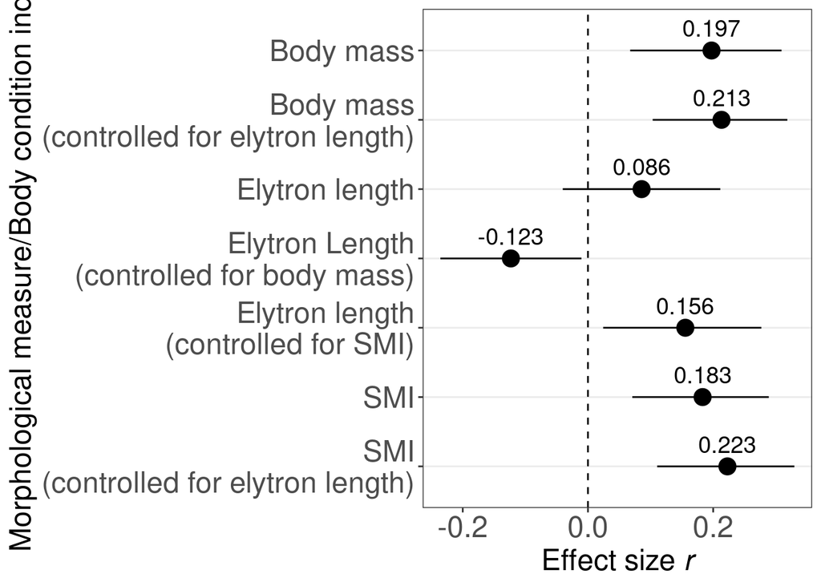

```r
(p_new + geom_text(aes(label = round(effect.size,
    3)), vjust = -0.8, size = 5))
```

## Is the cost of size on fitness dependent on resource availability during the larval and adult stages?

In this next section, we investigated whether the effect of food limitation at the larval and/or adult stage changes the relationship between fecundity and elytron length/mass/body condition. We expected that food limitation at the larval and/or the adult stage would accentuate a potential cost to structural size and we therefore expected statistical support for the effect of an interaction between body condition and feeding treatment on fecundity.

```r
M5.nb <- glm.nb(eggs ~ milieu * moyLong + milieu *
    MSL, na.action = na.fail, data = Fecond)
(gg5.nb <- dredge(M5.nb, rank = "AICc", extra = "R^2"))
```

```
## Global model call: glm.nb(formula = eggs ~ milieu * moyLong + milieu * MSL, data = Fecond,
##     na.action = na.fail, init.theta = 4.526294988, link = log)
## ---
## Model selection table
##    (Int) mil      myL      MSL mil:myL mil:MSL      R^2 df    logLik   AICc
## 24 1.918   + 0.179500 0.007903               + 0.198300 10 -1115.436 2251.9
## 32 3.533   + 0.016050 0.007197       +       + 0.211200 13 -1113.635 2255.0
## 8  1.670   + 0.175800 0.010230                 0.161200  7 -1120.437 2255.4
## 16 3.061   + 0.022380 0.010600       +         0.181700 10 -1117.702 2256.5
## 22 3.693   +          0.007116               + 0.169700  9 -1119.304 2257.5
## 6  3.612   +          0.007784                 0.133700  6 -1124.001 2260.4
## 4  3.624   + 0.099910                          0.111500  6 -1126.790 2266.0
## 2  4.559   +                                   0.101700  5 -1128.006 2266.3
## 12 4.542   + 0.001875                +         0.129800  9 -1124.490 2267.8
## 7  1.809     0.152900 0.009882                 0.054510  4 -1133.662 2275.5
```

[output cut: 18 more lines]

```r
M6.nb <- glm.nb(eggs ~ milieu * poids, na.action = na.fail,
    data = Fecond)

F1.nb <- glm.nb(eggs ~ moyLong + milieu * MSL,
    na.action = na.fail, data = Fecond)
F2.nb <- glm.nb(eggs ~ milieu * moyLong + milieu *
    MSL, na.action = na.fail, data = Fecond)
F3.nb <- glm.nb(eggs ~ milieu + moyLong + MSL,
    na.action = na.fail, data = Fecond)
F4.nb <- glm.nb(eggs ~ milieu * moyLong + MSL,
    na.action = na.fail, data = Fecond)
F5.nb <- glm.nb(eggs ~ milieu * MSL, na.action = na.fail,
    data = Fecond)
F6.nb <- glm.nb(eggs ~ milieu + poids, na.action = na.fail,
    data = Fecond)
F7.nb <- glm.nb(eggs ~ milieu + MSL, na.action = na.fail,
    data = Fecond)
F8.nb <- glm.nb(eggs ~ milieu * poids, na.action = na.fail,
    data = Fecond)
F9.nb <- glm.nb(eggs ~ milieu + moyLong, na.action = na.fail,
    data = Fecond)
F10.nb <- glm.nb(eggs ~ milieu, na.action = na.fail,
    data = Fecond)
F11.nb <- glm.nb(eggs ~ milieu * moyLong, na.action = na.fail,
    data = Fecond)
F12.nb <- glm.nb(eggs ~ moyLong + MSL, na.action = na.fail,
    data = Fecond)
F13.nb <- glm.nb(eggs ~ poids, na.action = na.fail,
    data = Fecond)
F14.nb <- glm.nb(eggs ~ MSL, na.action = na.fail,
    data = Fecond)
F15.nb <- glm.nb(eggs ~ 1, na.action = na.fail,
    data = Fecond)
F16.nb <- glm.nb(eggs ~ moyLong, na.action = na.fail,
    data = Fecond)

(ModelSel <- model.sel(F1.nb, F2.nb, F3.nb, F4.nb,
    F5.nb, F6.nb, F7.nb, F8.nb, F9.nb, F10.nb,
    F11.nb, F12.nb, F13.nb, F14.nb, F15.nb, F16.nb,
    rank = AICc))
```

```
## Model selection table
##        (Int) mil      myL      MSL mil:MSL mil:myL      pds mil:pds
## F1.nb  1.918   + 0.179500 0.007903       +
## F2.nb  3.533   + 0.016050 0.007197       +       +
## F3.nb  1.670   + 0.175800 0.010230
## F4.nb  3.061   + 0.022380 0.010600               +
## F5.nb  3.693   +          0.007116       +
## F6.nb  3.903   +                                   0.005700
## F7.nb  3.612   +          0.007784
## F8.nb  4.334   +                                   0.001940       +
## F9.nb  3.624   + 0.099910
## F10.nb 4.559   +
## F11.nb 4.542   + 0.001875                        +
## F12.nb 1.809     0.152900 0.009882
## F13.nb 3.825                                       0.005228
## F14.nb 3.525              0.007728
## F15.nb 4.449
## F16.nb 3.676     0.081070
##              family init.theta df    logLik   AICc delta weight
## F1.nb  NB(4.4503,l)       4.45 10 -1115.436 2251.9  0.00  0.615
## F2.nb  NB(4.5263,l)       4.53 13 -1113.635 2255.0  3.11  0.130
## F3.nb  NB(4.2467,l)       4.25  7 -1120.437 2255.4  3.48  0.108
## F4.nb  NB(4.3565,l)       4.36 10 -1117.702 2256.5  4.53  0.064
## F5.nb  NB(4.2912,l)       4.29  9 -1119.304 2257.5  5.54  0.039
## F6.nb  NB(4.1571,l)       4.16  6 -1122.749 2257.9  5.97  0.031
## F7.nb  NB(4.1084,l)       4.11  6 -1124.001 2260.4  8.47  0.009
## F8.nb  NB(4.2043,l)        4.2  9 -1121.511 2261.9  9.96  0.004
## F9.nb  NB(4.0052,l)       4.01  6 -1126.790 2266.0 14.05  0.001
## F10.nb NB(3.9602,l)       3.96  5 -1128.006 2266.3 14.37  0.000
## F11.nb NB(4.0914,l)       4.09  9 -1124.490 2267.8 15.91  0.000
## F12.nb NB(3.7593,l)       3.76  4 -1133.662 2275.5 23.59  0.000
## F13.nb NB(3.6889,l)       3.69  3 -1135.732 2277.6 25.65  0.000
## F14.nb NB(3.6738,l)       3.67  3 -1136.192 2278.5 26.57  0.000
## F15.nb NB(3.5537,l)       3.55  2 -1139.856 2283.8 31.85  0.000
## F16.nb NB(3.5779,l)       3.58  3 -1139.106 2284.3 32.40  0.000
## Abbreviations:
##  family: NB(3.5537,l) = 'Negative Binomial(3.5537,log)',
##          NB(3.5779,l) = 'Negative Binomial(3.5779,log)',
##          NB(3.6738,l) = 'Negative Binomial(3.6738,log)',
##          NB(3.6889,l) = 'Negative Binomial(3.6889,log)',
##          NB(3.7593,l) = 'Negative Binomial(3.7593,log)',
##          NB(3.9602,l) = 'Negative Binomial(3.9602,log)',
##          NB(4.0052,l) = 'Negative Binomial(4.0052,log)',
##          NB(4.0914,l) = 'Negative Binomial(4.0914,log)',
##          NB(4.1084,l) = 'Negative Binomial(4.1084,log)',
##          NB(4.1571,l) = 'Negative Binomial(4.1571,log)',
##          NB(4.2043,l) = 'Negative Binomial(4.2043,log)',
##          NB(4.2467,l) = 'Negative Binomial(4.2467,log)',
##          NB(4.2912,l) = 'Negative Binomial(4.2912,log)',
##          NB(4.3565,l) = 'Negative Binomial(4.3565,log)',
##          NB(4.4503,l) = 'Negative Binomial(4.4503,log)',
##          NB(4.5263,l) = 'Negative Binomial(4.5263,log)'
## Models ranked by AICc(x)
```

```r
R2 <- c(r.squaredLR(F1.nb), r.squaredLR(F2.nb),
    r.squaredLR(F3.nb), r.squaredLR(F4.nb), r.squaredLR(F5.nb),
    r.squaredLR(F6.nb), r.squaredLR(F7.nb), r.squaredLR(F8.nb),
    r.squaredLR(F9.nb), r.squaredLR(F10.nb), r.squaredLR(F11.nb),
    r.squaredLR(F12.nb), r.squaredLR(F13.nb),
    r.squaredLR(F14.nb), r.squaredLR(F15.nb),
    r.squaredLR(F16.nb))

ModelSel$R2 <- R2

write.table(ModelSel, "/home/mark/Dropbox/condition/ANALYSE/FinalAnalysis/eggsMSLLong.txt",
    sep = "\t")
```

Effect sizes of different effects

```r
r.part <- function(formula, data, indices) {
    d <- data[indices, ]  # allows boot to select sample
    fit <- glm.nb(formula, data = d)
    return(partial.r(coef(summary(fit))[2, 3],
        51))
}

(results <- boot(data = Fecond[which(Fecond$milieu ==
    "NlPNa"), ], statistic = r.part, R = 10000,
    formula = eggs ~ MSL + moyLong))
```

```
##
## ORDINARY NONPARAMETRIC BOOTSTRAP
##
##
## Call:
## boot(data = Fecond[which(Fecond$milieu == "NlPNa"), ], statistic = r.part,
##     R = 10000, formula = eggs ~ MSL + moyLong)
##
##
## Bootstrap Statistics :
##      original       bias    std. error
## t1* 0.4761921 -0.001472453  0.09300505
```

```r
set.seed(1)
(Boot <- boot.ci(results, type = "bca"))
```

```
## BOOTSTRAP CONFIDENCE INTERVAL CALCULATIONS
## Based on 10000 bootstrap replicates
##
## CALL :
## boot.ci(boot.out = results, type = "bca")
##
## Intervals :
## Level       BCa
## 95%   ( 0.2722,  0.6367 )
## Calculations and Intervals on Original Scale
```

```r
r.part <- function(formula, data, indices) {
    d <- data[indices, ]  # allows boot to select sample
    fit <- glm.nb(formula, data = d)
    return(partial.r(coef(summary(fit))[2, 3],
        53))
}

(results <- boot(data = Fecond[which(Fecond$milieu ==
    "NlNa"), ], statistic = r.part, R = 10000,
    formula = eggs ~ MSL + moyLong))
```

```
##
## ORDINARY NONPARAMETRIC BOOTSTRAP
##
##
## Call:
## boot(data = Fecond[which(Fecond$milieu == "NlNa"), ], statistic = r.part,
##     R = 10000, formula = eggs ~ MSL + moyLong)
##
##
## Bootstrap Statistics :
##      original    bias    std. error
## t1* 0.1482804 0.0077357   0.1227373
```

```r
set.seed(1)
(Boot <- boot.ci(results, type = "bca"))
```

```
## BOOTSTRAP CONFIDENCE INTERVAL CALCULATIONS
## Based on 10000 bootstrap replicates
##
## CALL :
## boot.ci(boot.out = results, type = "bca")
##
## Intervals :
## Level       BCa
## 95%   (-0.1243,  0.3651 )
## Calculations and Intervals on Original Scale
```

```r
r.part <- function(formula, data, indices) {
    d <- data[indices, ]  # allows boot to select sample
    fit <- glm.nb(formula, data = d)
    return(partial.r(coef(summary(fit))[2, 3],
        52))
}

(results <- boot(data = Fecond[which(Fecond$milieu ==
    "PNlNa"), ], statistic = r.part, R = 10000,
    formula = eggs ~ MSL + moyLong))
```

```
##
## ORDINARY NONPARAMETRIC BOOTSTRAP
##
##
## Call:
## boot(data = Fecond[which(Fecond$milieu == "PNlNa"), ], statistic = r.part,
##     R = 10000, formula = eggs ~ MSL + moyLong)
##
##
## Bootstrap Statistics :
##      original       bias    std. error
## t1* 0.2057181 -0.003225795   0.1564369
```

```r
set.seed(1)
(Boot <- boot.ci(results, type = "bca"))
```

```
## BOOTSTRAP CONFIDENCE INTERVAL CALCULATIONS
## Based on 10000 bootstrap replicates
##
## CALL :
## boot.ci(boot.out = results, type = "bca")
##
## Intervals :
## Level       BCa
## 95%   (-0.1296,  0.4785 )
## Calculations and Intervals on Original Scale
```

```r
r.part <- function(formula, data, indices) {
    d <- data[indices, ]  # allows boot to select sample
    fit <- glm.nb(formula, data = d)
    return(partial.r(coef(summary(fit))[2, 3],
        53))
}

(results <- boot(data = Fecond[which(Fecond$milieu ==
    "PNlPNa"), ], statistic = r.part, R = 10000,
    formula = eggs ~ MSL + moyLong))
```

```
##
## ORDINARY NONPARAMETRIC BOOTSTRAP
##
##
## Call:
## boot(data = Fecond[which(Fecond$milieu == "PNlPNa"), ], statistic = r.part,
##     R = 10000, formula = eggs ~ MSL + moyLong)
##
##
## Bootstrap Statistics :
##      original       bias    std. error
## t1* 0.1262508 -0.008823204   0.1204201
```

```r
set.seed(1)
(Boot <- boot.ci(results, type = "bca"))
```

```
## BOOTSTRAP CONFIDENCE INTERVAL CALCULATIONS
## Based on 10000 bootstrap replicates
##
## CALL :
## boot.ci(boot.out = results, type = "bca")
##
## Intervals :
## Level       BCa
## 95%   (-0.0984,  0.3713 )
## Calculations and Intervals on Original Scale
```

```r
partial.d <- function(t.val, df, n1, n2) {
    d <- t.val * (n1 + n2)/(sqrt(n1 * n2) * sqrt(df))
    names(d) <- "effect size d"
    return(d)
}

d.part <- function(formula, data, indices) {
    d <- data[indices, ]  # allows boot to select sample
    fit <- lm(formula, data = d)
    return(partial.d(coef(summary(fit))[2, 3],
        325, 182, 145))
}

# bootstrapping with 10000 replications
(results <- boot(data = INDICES, statistic = d.part,
    R = 10000, formula = moyLong ~ TreatLarve))
```

```
##
## ORDINARY NONPARAMETRIC BOOTSTRAP
##
##
## Call:
## boot(data = INDICES, statistic = d.part, R = 10000, formula = moyLong ~
##     TreatLarve)
##
##
## Bootstrap Statistics :
##      original      bias    std. error
## t1* 0.3543114 0.003089183   0.1197947
```

```r
set.seed(1)
(Boot <- boot.ci(results, type = "bca"))
```

```
## BOOTSTRAP CONFIDENCE INTERVAL CALCULATIONS
## Based on 10000 bootstrap replicates
##
## CALL :
## boot.ci(boot.out = results, type = "bca")
##
## Intervals :
## Level       BCa
## 95%   ( 0.1228,  0.5966 )
## Calculations and Intervals on Original Scale
```

```r
d.part <- function(formula, data, indices) {
    d <- data[indices, ]  # allows boot to select sample
    fit <- lm(formula, data = d)
    return(partial.d(coef(summary(fit))[2, 3],
        325, 182, 145))
}

# bootstrapping with 10000 replications
(results <- boot(data = INDICES, statistic = d.part,
    R = 10000, formula = poids ~ TreatLarve))
```

```
##
## ORDINARY NONPARAMETRIC BOOTSTRAP
##
##
## Call:
## boot(data = INDICES, statistic = d.part, R = 10000, formula = poids ~
##     TreatLarve)
##
##
## Bootstrap Statistics :
##      original      bias    std. error
## t1* 0.2878904 0.003262931   0.1149921
```

```r
set.seed(1)
(Boot <- boot.ci(results, type = "bca"))
```

```
## BOOTSTRAP CONFIDENCE INTERVAL CALCULATIONS
## Based on 10000 bootstrap replicates
##
## CALL :
## boot.ci(boot.out = results, type = "bca")
##
## Intervals :
## Level       BCa
## 95%   ( 0.0655,  0.5188 )
## Calculations and Intervals on Original Scale
```

```r
d.part <- function(formula, data, indices) {
    d <- data[indices, ]  # allows boot to select sample
    fit <- lm(formula, data = d)
    return(partial.d(coef(summary(fit))[2, 3],
        325, 182, 145))
}

# bootstrapping with 10000 replications
(results <- boot(data = INDICES, statistic = d.part,
    R = 10000, formula = SMI ~ TreatLarve))
```

```
##
## ORDINARY NONPARAMETRIC BOOTSTRAP
##
##
## Call:
## boot(data = INDICES, statistic = d.part, R = 10000, formula = SMI ~
##     TreatLarve)
##
##
## Bootstrap Statistics :
##       original       bias    std. error
## t1* -0.1000919 -0.001222959   0.1118269
```

```r
set.seed(1)
(Boot <- boot.ci(results, type = "bca"))
```

```
## BOOTSTRAP CONFIDENCE INTERVAL CALCULATIONS
## Based on 10000 bootstrap replicates
##
## CALL :
## boot.ci(boot.out = results, type = "bca")
##
## Intervals :
## Level       BCa
## 95%   (-0.3190,  0.1174 )
## Calculations and Intervals on Original Scale
```

We assessed differences in homogeneity of variance in elytron size, mass and SMI between larval treatments using the Fligner-Killeen test. We then assessed mean differences between larval treatment groups using linear models for elytron length and mass and a general least square (GLS) model for SMI to control for significant heterogeneity

```r
fligner.test(SMI ~ TreatLarve, data = INDICES)
```

```
##
##  Fligner-Killeen test of homogeneity of variances
##
## data:  SMI by TreatLarve
## Fligner-Killeen:med chi-squared = 9.7122, df = 1, p-value = 0.001831
```

```r
fligner.test(moyLong ~ TreatLarve, data = INDICES)
```

```
##
##  Fligner-Killeen test of homogeneity of variances
##
## data:  moyLong by TreatLarve
## Fligner-Killeen:med chi-squared = 0.2886, df = 1, p-value = 0.5911
```

```r
fligner.test(poids ~ TreatLarve, data = INDICES)
```

```
##
##  Fligner-Killeen test of homogeneity of variances
##
## data:  poids by TreatLarve
## Fligner-Killeen:med chi-squared = 2.18, df = 1, p-value = 0.1398
```

```r
library(nlme)

M3 <- gls(SMI ~ TreatLarve, data = INDICES, weights = varIdent(form = ~1 |
    TreatLarve), na.action = na.fail)
anova(M3)
```

```
## Denom. DF: 325
##             numDF   F-value p-value
## (Intercept)     1 25006.011  <.0001
## TreatLarve      1     0.832  0.3622
```

Plot fitness effects as a function of feeding treatment

```r
Fecond$fmilieu <- factor(Fecond$milieu)
M10.nb <- glm.nb(eggs ~ fmilieu + MSL + moyLong,
    na.action = na.fail, data = Fecond)
tuk <- glht(M10.nb, linfct = mcp(fmilieu = "Tukey"))
summary(tuk)
```

```
##
##   Simultaneous Tests for General Linear Hypotheses
##
## Multiple Comparisons of Means: Tukey Contrasts
##
##
## Fit: glm.nb(formula = eggs ~ fmilieu + MSL + moyLong, data = Fecond,
##     na.action = na.fail, init.theta = 4.246694084, link = log)
##
## Linear Hypotheses:
##                     Estimate Std. Error z value Pr(>|z|)
## NlPNa - NlNa == 0   -0.33815    0.09595  -3.524  0.00244 **
## PNlNa - NlNa == 0    0.07496    0.09480   0.791  0.85870
## PNlPNa - NlNa == 0  -0.28867    0.09544  -3.025  0.01328 *
## PNlNa - NlPNa == 0   0.41311    0.09545   4.328  < 0.001 ***
## PNlPNa - NlPNa == 0  0.04948    0.09593   0.516  0.95536
## PNlPNa - PNlNa == 0 -0.36363    0.09468  -3.841  < 0.001 ***
## ---
## Signif. codes:  0 '***' 0.001 '**' 0.01 '*' 0.05 '.' 0.1 ' ' 1
## (Adjusted p values reported -- single-step method)
```

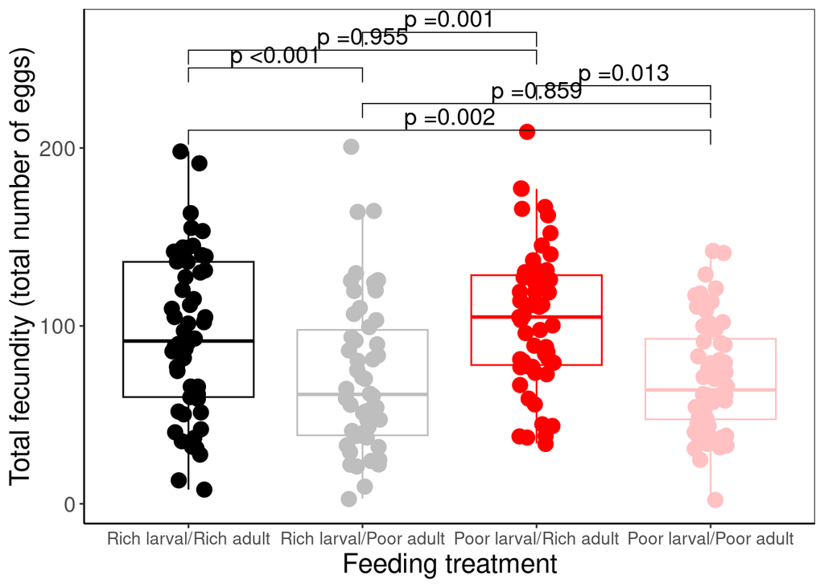

```r
SumTuk <- data.frame(cbind(Estimates = summary(tuk)$test$coefficients,
    Std.Error = summary(tuk)$test$sigma, zvalue = summary(tuk)$test$tstat,
    pvalues = summary(tuk)$test$pvalues), group1 = c("NlNa",
    "NlPNa", "PNlNa", "NlPNa", "PNlNa", "PNlNa"),
    group2 = c("PNlPNa", "PNlPNa", "PNlPNa", "NlNa",
        "NlNa", "NlPNa"))

SumTuk$p.adj <- finalfit::p_tidy(SumTuk$pvalues,
    digits = 3)

Eggs <- ggplot(Fecond, aes(y = eggs, x = milieu)) +
    geom_boxplot(outlier.shape = NA, aes(colour = milieu),
        show.legend = FALSE) + geom_jitter(position = position_jitter(0.1),
    aes(colour = milieu), size = 4) + theme_bw() +
    scale_colour_manual(values = c("black", "grey",
        "red", "rosybrown1"), name = "Feeding treatment:",
        breaks = c("NlNa", "NlPNa", "PNlNa", "PNlPNa"),
        labels = c("Rich larval/Rich adult", "Rich larval/Poor adult",
            "Poor larval/Rich adult", "Poor larval/Poor adult")) +
    labs(x = "Feeding treatment", y = "Total fecundity (total number of eggs)") +
    scale_x_discrete(labels = c(NlNa = "Rich larval/Rich adult",
        NlPNa = "Rich larval/Poor adult", PNlNa = "Poor larval/Rich adult",
        PNlPNa = "Poor larval/Poor adult")) +
    theme(plot.title = element_text(size = rel(1.5)),
        axis.text.y = element_text(size = rel(1.5)),
        axis.text.x = element_text(size = rel(1.2)),
        axis.title.x = element_text(size = rel(1.5)),
        axis.title.y = element_text(size = rel(1.5)),
        legend.text = element_text(size = rel(1.5)),
        legend.title = element_text(size = rel(1.5)),
        panel.grid.major = element_blank(), panel.grid.minor = element_blank(),
        panel.background = element_blank(), axis.line = element_line(colour = "black")) +
    stat_pvalue_manual(SumTuk, label = "p {p.adj}",
        y.position = c(210, 225, 235, 245, 255,
            265), size = 5)

Eggs + theme(legend.position = "none")
```

```r
png("/home/mark/Dropbox/condition/apres JEB/FigureBoxplotOeufsMilieuNew.png",
    width = 2100, height = 2100, res = 300)

Eggs + theme(legend.position = "none")

dev.off()
```

Plot fitness effects as a function of feeding treatment and body mass/elytron length/SMI.

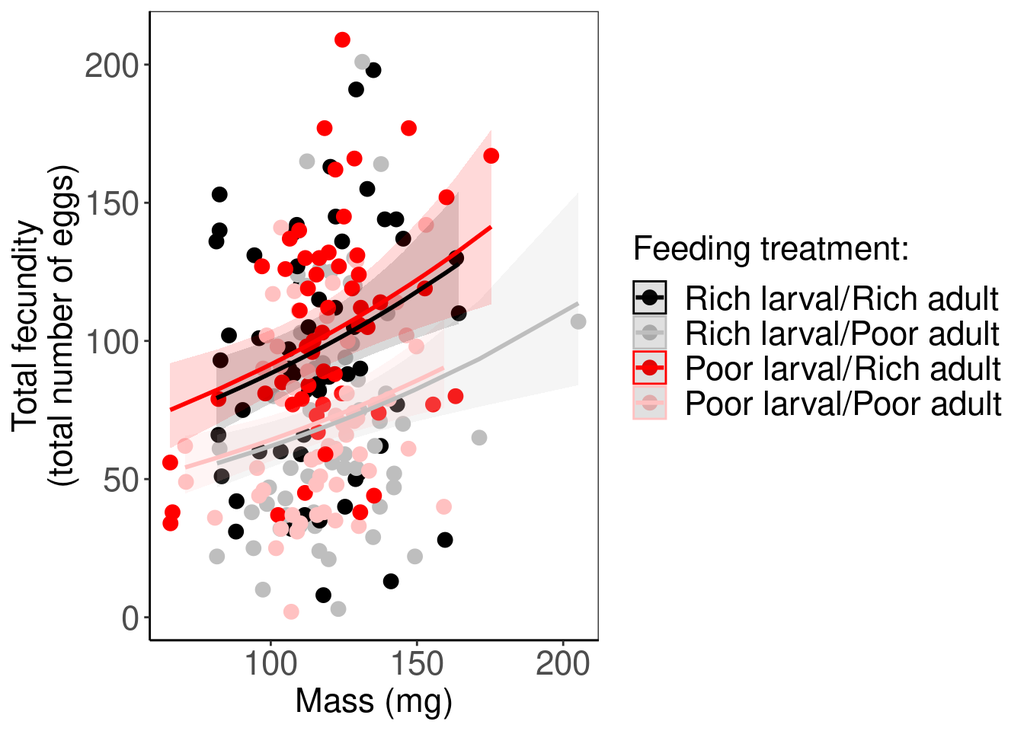

```r
Fit <- glm.nb(eggs ~ poids + TreatLarve + TreatAdult,
    na.action = na.fail, data = Fecond)
newdat = data.frame(TreatAdult = Fecond$TreatAdult,
    poids = Fecond$poids, eggs = Fecond$eggs,
    TreatLarve = Fecond$TreatLarve)
pred = predict(Fit, newdata = newdat, level = 0,
    interval = "confidence")
des = model.matrix(formula("~poids+TreatAdult+TreatLarve"),
    newdat)
predvar = diag(des %*% vcov(Fit) %*% t(des))
newdat$lower = with(newdat, pred - 1.96 * sqrt(predvar))
newdat$upper = with(newdat, pred + 1.96 * sqrt(predvar))
newdat$Treat <- factor(interaction(newdat$TreatLarve,
    newdat$TreatAdult))


(Eggspoids <- ggplot(newdat, aes(x = poids, y = eggs,
    color = Treat)) + geom_point(aes(x = poids,
    y = eggs), size = 3) + geom_ribbon(data = newdat,
    aes(y = NULL, ymin = exp(lower), ymax = exp(upper),
        color = NULL, fill = Treat), alpha = 0.15) +
    geom_line(data = newdat, aes(y = exp(pred)),
        size = 1) + theme_bw() + scale_colour_manual(values = c("black",
    "grey", "red", "rosybrown1"), name = "Feeding treatment:",
    breaks = c("N.N", "N.PN", "PN.N", "PN.PN"),
    labels = c("Rich larval/Rich adult", "Rich larval/Poor adult",
        "Poor larval/Rich adult", "Poor larval/Poor adult")) +
    theme(plot.title = element_text(size = rel(1.5)),
        axis.text = element_text(size = rel(1.5)),
        axis.title.x = element_text(size = rel(1.5)),
        axis.title.y = element_text(size = rel(1.5)),
        legend.text = element_text(size = rel(1.5)),
        legend.title = element_text(size = rel(1.5)),
        panel.grid.major = element_blank(), panel.grid.minor = element_blank(),
        panel.background = element_blank(), axis.line = element_line(colour = "black")) +
    labs(x = "Mass (mg)", y = "Total fecundity\n(total number of eggs)") +
    scale_fill_manual(values = c("black", "grey",
        "red", "rosybrown1"), name = "fill", guide = FALSE,
        breaks = c("N.N", "N.PN", "PN.N", "PN.PN"),
        labels = c("Rich larval/Rich adult", "Rich larval/Poor adult",
            "Poor larval/Rich adult", "Poor larval/Poor adult")))
```

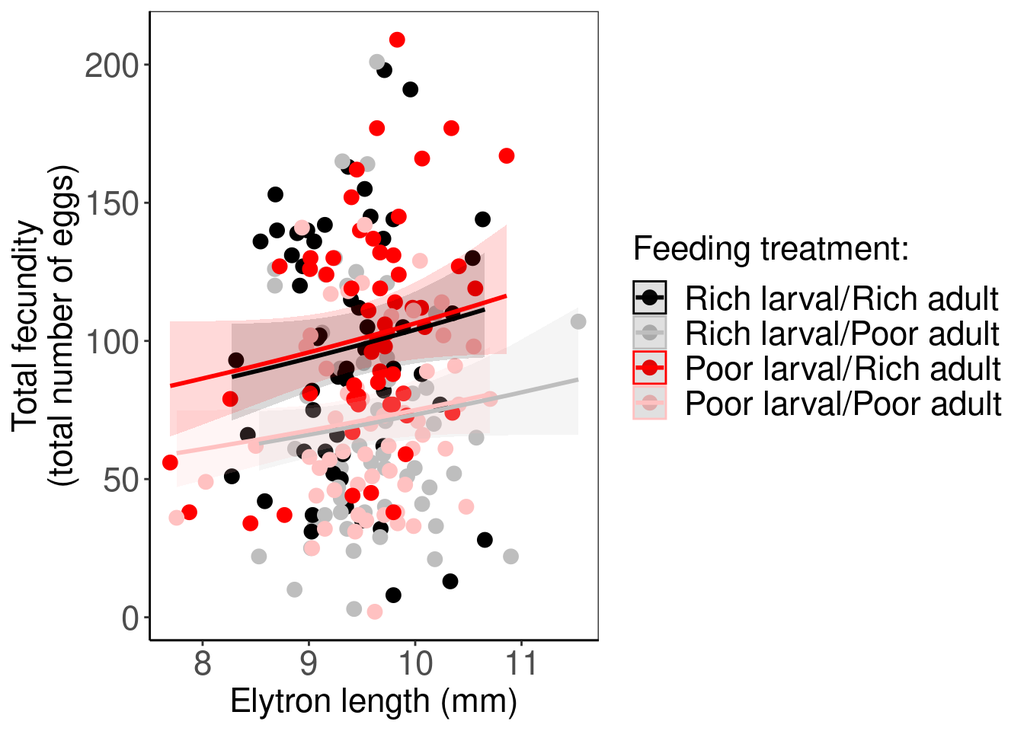

```r
Fit <- glm.nb(eggs ~ moyLong + TreatLarve + TreatAdult,
    na.action = na.fail, data = Fecond)
newdat = data.frame(TreatAdult = Fecond$TreatAdult,
    moyLong = Fecond$moyLong, eggs = Fecond$eggs,
    TreatLarve = Fecond$TreatLarve)
pred = predict(Fit, newdata = newdat, level = 0,
    interval = "confidence")
newdat <- cbind(newdat, pred)
des = model.matrix(formula("~moyLong+TreatAdult+TreatLarve"),
    newdat)
predvar = diag(des %*% vcov(Fit) %*% t(des))
newdat$lower = with(newdat, pred - 1.96 * sqrt(predvar))
newdat$upper = with(newdat, pred + 1.96 * sqrt(predvar))
newdat$Treat <- factor(interaction(newdat$TreatLarve,
    newdat$TreatAdult))


(EggsmoyLong <- ggplot(newdat, aes(x = moyLong,
    y = eggs, color = Treat)) + geom_point(aes(x = moyLong,
    y = eggs), size = 3) + geom_ribbon(data = newdat,
    aes(y = NULL, ymin = exp(lower), ymax = exp(upper),
        color = NULL, fill = Treat), alpha = 0.15) +
    geom_line(data = newdat, aes(y = exp(pred)),
        size = 1) + theme_bw() + scale_colour_manual(values = c("black",
    "grey", "red", "rosybrown1"), name = "Feeding treatment:",
    breaks = c("N.N", "N.PN", "PN.N", "PN.PN"),
    labels = c("Rich larval/Rich adult", "Rich larval/Poor adult",
        "Poor larval/Rich adult", "Poor larval/Poor adult")) +
    theme(plot.title = element_text(size = rel(1.5)),
        axis.text = element_text(size = rel(1.5)),
        axis.title.x = element_text(size = rel(1.5)),
        axis.title.y = element_text(size = rel(1.5)),
        legend.text = element_text(size = rel(1.5)),
        legend.title = element_text(size = rel(1.5)),
        panel.grid.major = element_blank(), panel.grid.minor = element_blank(),
        panel.background = element_blank(), axis.line = element_line(colour = "black")) +
    labs(x = "Elytron length (mm)", y = "Total fecundity\n(total number of eggs)") +
    scale_fill_manual(values = c("black", "grey",
        "red", "rosybrown1"), name = "fill", guide = FALSE,
        breaks = c("N.N", "N.PN", "PN.N", "PN.PN"),
        labels = c("Rich larval/Rich adult", "Rich larval/Poor adult",
            "Poor larval/Rich adult", "Poor larval/Poor adult")))
```

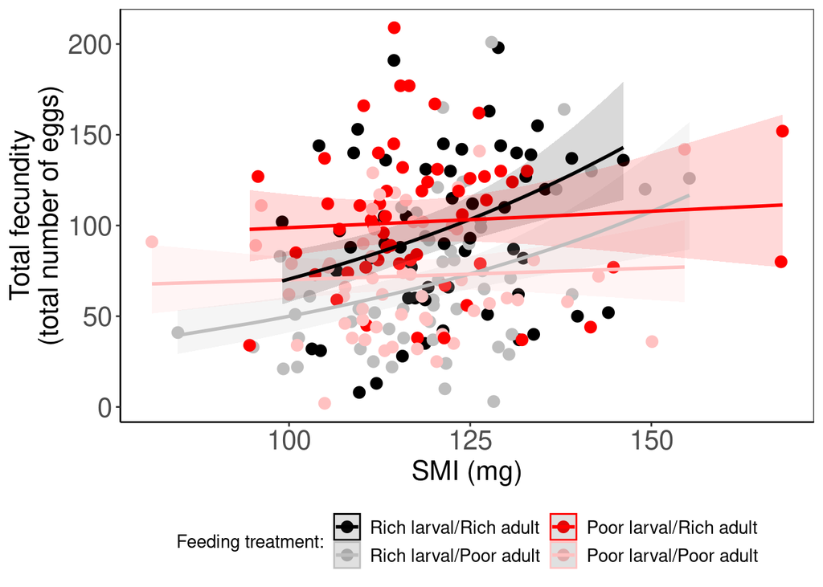

```r
Fit <- glm.nb(eggs ~ MSL * TreatLarve + TreatAdult,
    na.action = na.fail, data = Fecond)
newdat = data.frame(TreatAdult = Fecond$TreatAdult,
    MSL = Fecond$MSL, eggs = Fecond$eggs, TreatLarve = Fecond$TreatLarve)
pred = predict(Fit, newdata = newdat, level = 0,
    interval = "confidence")
newdat <- cbind(newdat, pred)
des = model.matrix(formula("~MSL*TreatLarve+TreatAdult"),
    newdat)
predvar = diag(des %*% vcov(Fit) %*% t(des))
newdat$lower = with(newdat, pred - 1.96 * sqrt(predvar))
newdat$upper = with(newdat, pred + 1.96 * sqrt(predvar))
newdat$Treat <- factor(interaction(newdat$TreatLarve,
    newdat$TreatAdult))



(EggsSMI <- ggplot(newdat, aes(x = MSL, y = eggs,
    color = Treat)) + geom_point(aes(x = MSL,
    y = eggs), size = 3) + geom_ribbon(data = newdat,
    aes(y = NULL, ymin = exp(lower), ymax = exp(upper),
        color = NULL, fill = Treat), alpha = 0.15) +
    geom_line(data = newdat, aes(y = exp(pred)),
        size = 1) + theme_bw() + scale_colour_manual(values = c("black",
    "grey", "red", "rosybrown1"), name = "Feeding treatment:",
    breaks = c("N.N", "N.PN", "PN.N", "PN.PN"),
    labels = c("Rich larval/Rich adult", "Rich larval/Poor adult",
        "Poor larval/Rich adult", "Poor larval/Poor adult"),
    guide = guide_legend(ncol = 2)) + theme(plot.title = element_text(size = rel(1.5)),
    axis.text = element_text(size = rel(1.5)),
    axis.title.x = element_text(size = rel(1.5)),
    axis.title.y = element_text(size = rel(1.5)),
    legend.text = element_text(size = rel(1.5)),
    legend.title = element_text(size = rel(1.5)),
    panel.grid.major = element_blank(), panel.grid.minor = element_blank(),
    panel.background = element_blank(), axis.line = element_line(colour = "black")) +
    labs(x = "SMI (mg)", y = "Total fecundity\n(total number of eggs)") +
    scale_fill_manual(values = c("black", "grey",
        "red", "rosybrown1"), name = "fill", guide = FALSE,
        breaks = c("N.N", "N.PN", "PN.N", "PN.PN"),
        labels = c("Rich larval/Rich adult", "Rich larval/Poor adult",
            "Poor larval/Rich adult", "Poor larval/Poor adult")) +
    theme(legend.position = "bottom", legend.text = element_text(size = rel(1)),
        legend.title = element_text(size = rel(1))))
```

Plot densities

```r
cdat <- INDICES %>%
    group_by(TreatLarve) %>%
    summarise(poids.mean = mean(poids), sem = sd(poids)/sqrt(length(poids)),
        upper.95 = quantile(poids, probs = c(0.975)),
        lower.95 = quantile(poids, probs = c(0.025)),
        ci.low = mean(poids) - 1.96 * sem, ci.upp = mean(poids) +
            1.96 * sem)
cdat
```

```
## # A tibble: 2 × 7
##   TreatLarve poids.mean   sem upper.95 lower.95 ci.low ci.upp
##   <chr>           <dbl> <dbl>    <dbl>    <dbl>  <dbl>  <dbl>
## 1 Nl               115.  1.64     161.     80.0   111.   118.
## 2 PNl              121.  1.64     160.     70.9   118.   124.
```

```r
cdat.dens <- ggplot_build(ggplot(INDICES, aes(x = poids,
    colour = TreatLarve)) + geom_density())$data[[1]] %>%
    mutate(TreatLarve = ifelse(group == 1, "Nl",
        "PNl")) %>%
    left_join(cdat) %>%
    dplyr::select(y, x, TreatLarve, poids.mean,
        sem, ci.low, ci.upp) %>%
    dplyr::group_by(TreatLarve) %>%
    dplyr::mutate(dens.mean = approx(x, y, xout = poids.mean)[[2]],
        dens.cilow = approx(x, y, xout = ci.low)[[2]],
        dens.ciupp = approx(x, y, xout = ci.upp)[[2]]) %>%
    dplyr::select(-y, -x) %>%
    slice(1)

ribbon <- ggplot_build(ggplot(INDICES, aes(x = poids,
    colour = TreatLarve)) + geom_density())$data[[1]] %>%
    mutate(TreatLarve = ifelse(group == 1, "Nl",
        "PNl")) %>%
    left_join(cdat.dens) %>%
    group_by(TreatLarve) %>%
    filter(x >= ci.low & x <= ci.upp) %>%
    dplyr::select(TreatLarve, x, y)


ribbon <- rbind(data.frame(TreatLarve = c("Nl",
    "PNl"), x = c(cdat.dens$ci.low[cdat.dens$TreatLarve ==
    "Nl"], cdat.dens$ci.low[cdat.dens$TreatLarve ==
    "PNl"]), y = c(0, 0)), as.data.frame(ribbon),
    data.frame(TreatLarve = c("Nl", "PNl"), x = c(cdat.dens$ci.upp[cdat.dens$TreatLarve ==
        "Nl"], cdat.dens$ci.upp[cdat.dens$TreatLarve ==
        "PNl"]), y = c(0, 0)))

names(ribbon)
```

```
## [1] "TreatLarve" "x"          "y"
```

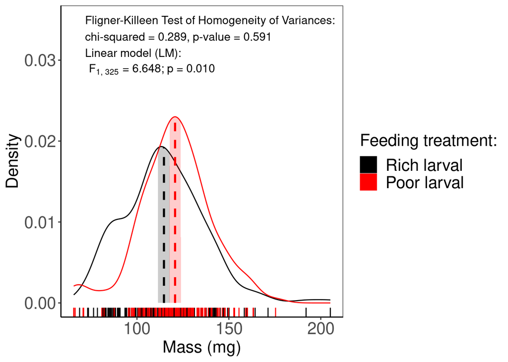

```r
label2 <- expression(~"\tF"[1][", "][325] ~ "= 6.648; p = 0.010")



(DensityMass <- ggplot() + geom_density(data = INDICES,
    aes(x = poids, colour = TreatLarve)) + geom_rug(data = INDICES,
    aes(x = poids, colour = TreatLarve)) + geom_polygon(data = ribbon,
    aes(x = x, y = y, fill = TreatLarve), alpha = 0.2) +
    geom_segment(data = cdat.dens, aes(x = poids.mean,
        xend = poids.mean, y = 0, yend = dens.mean,
        colour = TreatLarve), linetype = "dashed",
        size = 1) + theme_bw() + scale_colour_manual(values = c("black",
    "red"), name = "Feeding treatment:", breaks = c("Nl",
    "PNl"), labels = c("Rich larval", "Poor larval")) +
    scale_fill_manual(values = c("black", "red"),
        name = "Feeding treatment:", breaks = c("Nl",
            "PNl"), labels = c("Rich larval",
            "Poor larval")) + annotate(geom = "text",
    x = -Inf, y = Inf, label = "\tFligner-Killeen Test of Homogeneity of Variances:\n\tchi-squared = 0.289, p-value = 0.591 \n\tLinear model (LM):",
    hjust = 0, vjust = 1.25, size = rel(4)) +
    annotate(geom = "text", x = -Inf, y = Inf,
        label = label2, hjust = 0, vjust = 5.75,
        size = rel(4)) + theme(plot.title = element_text(size = rel(1.5)),
    axis.text = element_text(size = rel(1.5)),
    axis.title.x = element_text(size = rel(1.5)),
    axis.title.y = element_text(size = rel(1.5)),
    legend.text = element_text(size = rel(1.5)),
    legend.title = element_text(size = rel(1.5)),
    panel.grid.major = element_blank(), panel.grid.minor = element_blank(),
    panel.background = element_blank(), axis.line = element_line(colour = "black")) +
    xlab("Mass (mg)") + ylab("Density") + ylim(0,
    0.035))
```

```r
cdat <- INDICES %>%
    group_by(TreatLarve) %>%
    summarise(moyLong.mean = mean(moyLong), sem = sd(moyLong)/sqrt(length(moyLong)),
        upper.95 = quantile(moyLong, probs = c(0.975)),
        lower.95 = quantile(moyLong, probs = c(0.025)),
        ci.low = mean(moyLong) - 1.96 * sem, ci.upp = mean(moyLong) +
            1.96 * sem)
cdat
```

```
## # A tibble: 2 × 7
##   TreatLarve moyLong.mean    sem upper.95 lower.95 ci.low ci.upp
##   <chr>             <dbl>  <dbl>    <dbl>    <dbl>  <dbl>  <dbl>
## 1 Nl                 9.46 0.0437     10.7     8.40   9.38   9.55
## 2 PNl                9.67 0.0487     10.7     8.17   9.58   9.77
```

```r
cdat.dens <- ggplot_build(ggplot(INDICES, aes(x = moyLong,
    colour = TreatLarve)) + geom_density())$data[[1]] %>%
    mutate(TreatLarve = ifelse(group == 1, "Nl",
        "PNl")) %>%
    left_join(cdat) %>%
    dplyr::select(y, x, TreatLarve, moyLong.mean,
        sem, ci.low, ci.upp) %>%
    dplyr::group_by(TreatLarve) %>%
    dplyr::mutate(dens.mean = approx(x, y, xout = moyLong.mean)[[2]],
        dens.cilow = approx(x, y, xout = ci.low)[[2]],
        dens.ciupp = approx(x, y, xout = ci.upp)[[2]]) %>%
    dplyr::select(-y, -x) %>%
    slice(1)

ribbon <- ggplot_build(ggplot(INDICES, aes(x = moyLong,
    colour = TreatLarve)) + geom_density())$data[[1]] %>%
    mutate(TreatLarve = ifelse(group == 1, "Nl",
        "PNl")) %>%
    left_join(cdat.dens) %>%
    group_by(TreatLarve) %>%
    filter(x >= ci.low & x <= ci.upp) %>%
    dplyr::select(TreatLarve, x, y)


ribbon <- rbind(data.frame(TreatLarve = c("Nl",
    "PNl"), x = c(cdat.dens$ci.low[cdat.dens$TreatLarve ==
    "Nl"], cdat.dens$ci.low[cdat.dens$TreatLarve ==
    "PNl"]), y = c(0, 0)), as.data.frame(ribbon),
    data.frame(TreatLarve = c("Nl", "PNl"), x = c(cdat.dens$ci.upp[cdat.dens$TreatLarve ==
        "Nl"], cdat.dens$ci.upp[cdat.dens$TreatLarve ==
        "PNl"]), y = c(0, 0)))

names(ribbon)
```

```
## [1] "TreatLarve" "x"          "y"
```

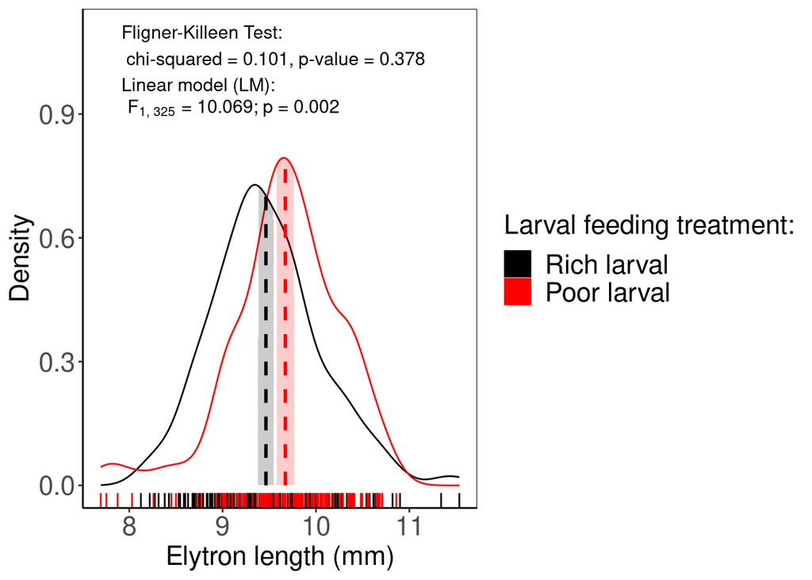

```r
label2 <- expression(~"\tF"[1][", "][325] ~ "= 10.069; p = 0.002")



(DensityLong <- ggplot() + geom_density(data = INDICES,
    aes(x = moyLong, colour = TreatLarve)) + geom_rug(data = INDICES,
    aes(x = moyLong, colour = TreatLarve)) + geom_polygon(data = ribbon,
    aes(x = x, y = y, fill = TreatLarve), alpha = 0.2) +
    geom_segment(data = cdat.dens, aes(x = moyLong.mean,
        xend = moyLong.mean, y = 0, yend = dens.mean,
        colour = TreatLarve), linetype = "dashed",
        size = 1) + theme_bw() + scale_colour_manual(values = c("black",
    "red"), name = "Larval feeding treatment:",
    breaks = c("Nl", "PNl"), labels = c("Rich larval",
        "Poor larval")) + scale_fill_manual(values = c("black",
    "red"), name = "Larval feeding treatment:",
    breaks = c("Nl", "PNl"), labels = c("Rich larval",
        "Poor larval")) + annotate(geom = "text",
    x = -Inf, y = Inf, label = "\tFligner-Killeen Test:\n\t chi-squared = 0.101, p-value = 0.378 \n\tLinear model (LM):",
    hjust = 0, vjust = 1.25, size = rel(4)) +
    annotate(geom = "text", x = -Inf, y = Inf,
        label = label2, hjust = 0, vjust = 5.75,
        size = rel(4)) + theme(plot.title = element_text(size = rel(1.5)),
    axis.text = element_text(size = rel(1.5)),
    axis.title.x = element_text(size = rel(1.5)),
    axis.title.y = element_text(size = rel(1.5)),
    legend.text = element_text(size = rel(1.5)),
    legend.title = element_text(size = rel(1.5)),
    panel.grid.major = element_blank(), panel.grid.minor = element_blank(),
    panel.background = element_blank(), axis.line = element_line(colour = "black")) +
    xlab("Elytron length (mm)") + ylab("Density") +
    ylim(0, 1.1))
```

```r
cdat <- INDICES %>%
    group_by(TreatLarve) %>%
    summarise(SMI.mean = mean(SMI), sem = sd(SMI)/sqrt(length(SMI)),
        upper.95 = quantile(SMI, probs = c(0.975)),
        lower.95 = quantile(SMI, probs = c(0.025)),
        ci.low = mean(SMI) - 1.96 * sem, ci.upp = mean(SMI) +
            1.96 * sem)
cdat
```

```
## # A tibble: 2 × 7
##   TreatLarve SMI.mean   sem upper.95 lower.95 ci.low ci.upp
##   <chr>         <dbl> <dbl>    <dbl>    <dbl>  <dbl>  <dbl>
## 1 Nl             117.  1.07     144.     87.3   115.   120.
## 2 PNl            116.  1.02     147.     96.0   114.   118.
```

```r
cdat.dens <- ggplot_build(ggplot(INDICES, aes(x = SMI,
    colour = TreatLarve)) + geom_density())$data[[1]] %>%
    mutate(TreatLarve = ifelse(group == 1, "Nl",
        "PNl")) %>%
    left_join(cdat) %>%
    dplyr::select(y, x, TreatLarve, SMI.mean,
        sem, ci.low, ci.upp) %>%
    dplyr::group_by(TreatLarve) %>%
    dplyr::mutate(dens.mean = approx(x, y, xout = SMI.mean)[[2]],
        dens.cilow = approx(x, y, xout = ci.low)[[2]],
        dens.ciupp = approx(x, y, xout = ci.upp)[[2]]) %>%
    dplyr::select(-y, -x) %>%
    slice(1)

ribbon <- ggplot_build(ggplot(INDICES, aes(x = SMI,
    colour = TreatLarve)) + geom_density())$data[[1]] %>%
    mutate(TreatLarve = ifelse(group == 1, "Nl",
        "PNl")) %>%
    left_join(cdat.dens) %>%
    dplyr::group_by(TreatLarve) %>%
    filter(x >= ci.low & x <= ci.upp) %>%
    dplyr::select(TreatLarve, x, y)


ribbon <- rbind(data.frame(TreatLarve = c("Nl",
    "PNl"), x = c(cdat.dens$ci.low[cdat.dens$TreatLarve ==
    "Nl"], cdat.dens$ci.low[cdat.dens$TreatLarve ==
    "PNl"]), y = c(0, 0)), as.data.frame(ribbon),
    data.frame(TreatLarve = c("Nl", "PNl"), x = c(cdat.dens$ci.upp[cdat.dens$TreatLarve ==
        "Nl"], cdat.dens$ci.upp[cdat.dens$TreatLarve ==
        "PNl"]), y = c(0, 0)))

names(ribbon)
```

```
## [1] "TreatLarve" "x"          "y"
```

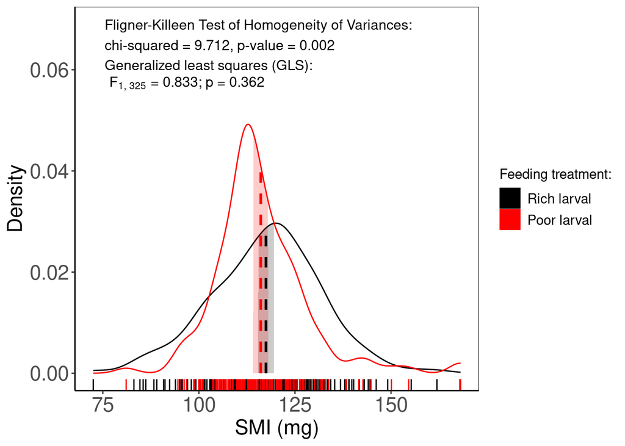

```r
label2 <- expression(~"\tF"[1][", "][325] ~ "= 0.833; p = 0.362")

(DensitySMI <- ggplot() + geom_density(data = INDICES,
    aes(x = SMI, colour = TreatLarve)) + geom_rug(data = INDICES,
    aes(x = SMI, colour = TreatLarve)) + geom_polygon(data = ribbon,
    aes(x = x, y = y, fill = TreatLarve), alpha = 0.2) +
    geom_segment(data = cdat.dens, aes(x = SMI.mean,
        xend = SMI.mean, y = 0, yend = dens.mean,
        colour = TreatLarve), linetype = "dashed",
        size = 1) + theme_bw() + scale_colour_manual(values = c("black",
    "red"), name = "Feeding treatment:", breaks = c("Nl",
    "PNl"), labels = c("Rich larval", "Poor larval")) +
    scale_fill_manual(values = c("black", "red"),
        name = "Feeding treatment:", breaks = c("Nl",
            "PNl"), labels = c("Rich larval",
            "Poor larval")) + annotate(geom = "text",
    x = -Inf, y = Inf, label = "\tFligner-Killeen Test of Homogeneity of Variances:\n\tchi-squared = 9.712, p-value = 0.002 \n\tGeneralized least squares (GLS):",
    hjust = 0, vjust = 1.25, size = rel(4)) +
    annotate(geom = "text", x = -Inf, y = Inf,
        label = label2, hjust = 0, vjust = 5.75,
        size = rel(4)) + theme(plot.title = element_text(size = rel(1.5)),
    axis.text = element_text(size = rel(1.5)),
    axis.title.x = element_text(size = rel(1.5)),
    axis.title.y = element_text(size = rel(1.5)),
    legend.text = element_text(size = rel(1)),
    legend.title = element_text(size = rel(1)),
    panel.grid.major = element_blank(), panel.grid.minor = element_blank(),
    panel.background = element_blank(), axis.line = element_line(colour = "black")) +
    xlab("SMI (mg)") + ylab("Density") + ylim(0,
    0.069))
```

Panel figure

```r
legend = gtable_filter(ggplotGrob(EggsmoyLong +
    theme(legend.text = element_text(size = rel(1.5)),
        legend.title = element_text(size = rel(1.5)))),
    "guide-box")
legend2 = gtable_filter(ggplotGrob(DensityLong +
    theme(legend.text = element_text(size = rel(1.5)),
        legend.title = element_text(size = rel(1.5)))),
    "guide-box")


png("/home/mark/Dropbox/condition/apres JEB/TotalFecondTraitSelection.png",
    height = 4200, width = 4200, res = 300)
pushViewport(viewport(layout = grid.layout(24,
    20)))
vplayout <- function(x, y) viewport(layout.pos.row = x,
    layout.pos.col = y)


print(DensityMass + theme(legend.position = "none") +
    ggtitle("a."), vp = vplayout(1:7, 1:8))
print(DensityLong + theme(legend.position = "none") +
    ggtitle("b."), vp = vplayout(8:14, 1:8))
print(DensitySMI + theme(legend.position = "none") +
    ggtitle("c."), vp = vplayout(15:21, 1:8))
legend2$vp = viewport(layout.pos.row = 22:23,
    layout.pos.col = 1:9)
grid.draw(legend2)


print(Eggspoids + theme(legend.position = "none") +
    ggtitle("d."), vp = vplayout(1:7, 10:19))
print(EggsmoyLong + theme(legend.position = "none") +
    ggtitle("f."), vp = vplayout(8:14, 10:19))
print(EggsSMI + theme(legend.position = "none") +
    ggtitle("f."), vp = vplayout(15:21, 10:19))
legend$vp = viewport(layout.pos.row = 22:24, layout.pos.col = 9:20)
grid.draw(legend)

dev.off()
```

## Supplementary information

Relationship between mass and elytron size according to OLS, SMA and MA regressions.

```r
INDICES$lpoids <- log10(INDICES$poids)
INDICES$lmoyLong <- log10(INDICES$moyLong)

M1 <- lmodel2(lpoids ~ lmoyLong, data = INDICES)
M1
```

```
##
## Model II regression
##
## Call: lmodel2(formula = lpoids ~ lmoyLong, data = INDICES)
##
## n = 327   r = 0.8056749   r-square = 0.649112
## Parametric P-values:   2-tailed = 6.740089e-76    1-tailed = 3.370044e-76
## Angle between the two OLS regression lines = 7.52442 degrees
##
## Regression results
##   Method  Intercept    Slope Angle (degrees) P-perm (1-tailed)
## 1    OLS -0.2729768 2.384260        67.24598                NA
## 2     MA -1.4014840 3.536462        74.21077                NA
## 3    SMA -0.8362235 2.959333        71.32917                NA
##
## Confidence intervals
##   Method 2.5%-Intercept 97.5%-Intercept 2.5%-Slope 97.5%-Slope
## 1    OLS     -0.4604109     -0.08554267   2.192965    2.575556
## 2     MA     -1.7017636     -1.14274454   3.272290    3.843046
## 3    SMA     -1.0296345     -0.65491120   2.774214    3.156805
##
## Eigenvalues: 0.007023285 0.0002426068
##
## H statistic used for computing C.I. of MA: 0.0004413169
```

```r
reg <- (M1$regression.results)
CI <- (M1$confidence.intervals)
reg <- merge(reg, CI, by = "Method")
# Rename columns in reg so they're easy to
# use
names(reg) <- c("method", "intercept", "slope",
    "angle", "p-value", "low.intercept", "high.intercept",
    "low.slope", "high.slope")
# Check that the regressions look like so we
# know what will be plots
print(reg)
```

```
##   method  intercept    slope    angle p-value low.intercept high.intercept
## 1     MA -1.4014840 3.536462 74.21077      NA    -1.7017636    -1.14274454
## 2    OLS -0.2729768 2.384260 67.24598      NA    -0.4604109    -0.08554267
## 3    SMA -0.8362235 2.959333 71.32917      NA    -1.0296345    -0.65491120
##   low.slope high.slope
## 1  3.272290   3.843046
## 2  2.192965   2.575556
## 3  2.774214   3.156805
```

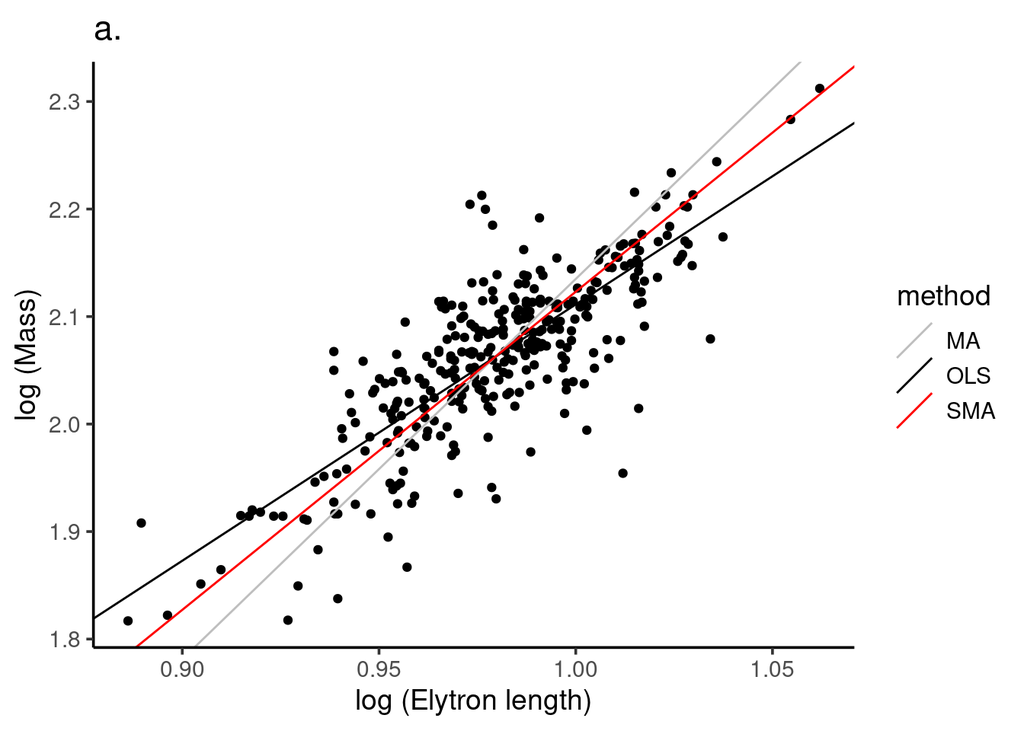

```r
M2 <- sma(poids ~ moyLong, log = "xy", data = INDICES)
M3 <- ma(poids ~ moyLong, log = "xy", data = INDICES)

INDICES$SMAresid <- residuals(M2)
INDICES$MAresid <- residuals(M3)

p1 <- ggplot() + geom_point(data = INDICES, aes(x = lmoyLong,
    y = lpoids)) + geom_abline(data = reg, aes(intercept = intercept,
    slope = slope, colour = method), show.legend = TRUE) +
    theme_classic(base_size = 14) + scale_color_manual(values = c("gray",
    "black", "red")) + labs(x = "log (Elytron length)",
    y = "log (Mass)") + ggtitle("a.")
p1
```

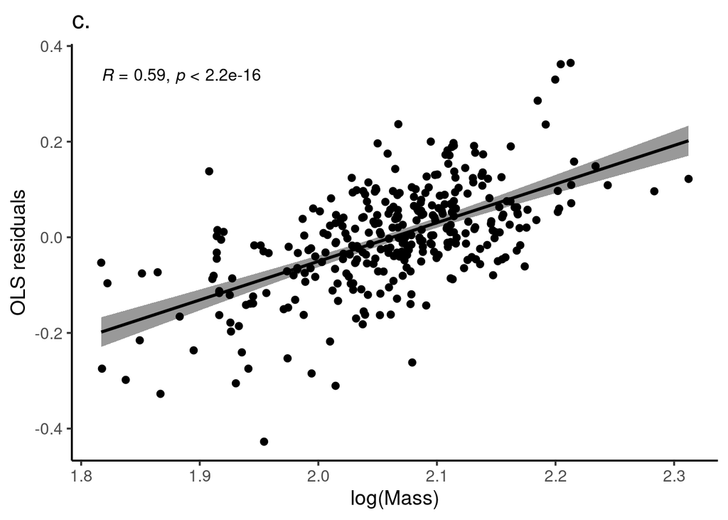

```r
MSLMA <- INDICES$poids * ((mean(INDICES$moyLong)/INDICES$moyLong)^3.536462)

INDICES$MSLMA <- MSLMA

p2 <- ggscatter(INDICES, x = "lpoids", y = "OLS",
    add = "reg.line", conf.int = TRUE, cor.coef = TRUE,
    cor.method = "pearson", xlab = "log(Mass)",
    ylab = "OLS residuals", cor.coef.size = 4) +
    ggtitle("c.") + theme_classic(base_size = 14)
p2
```

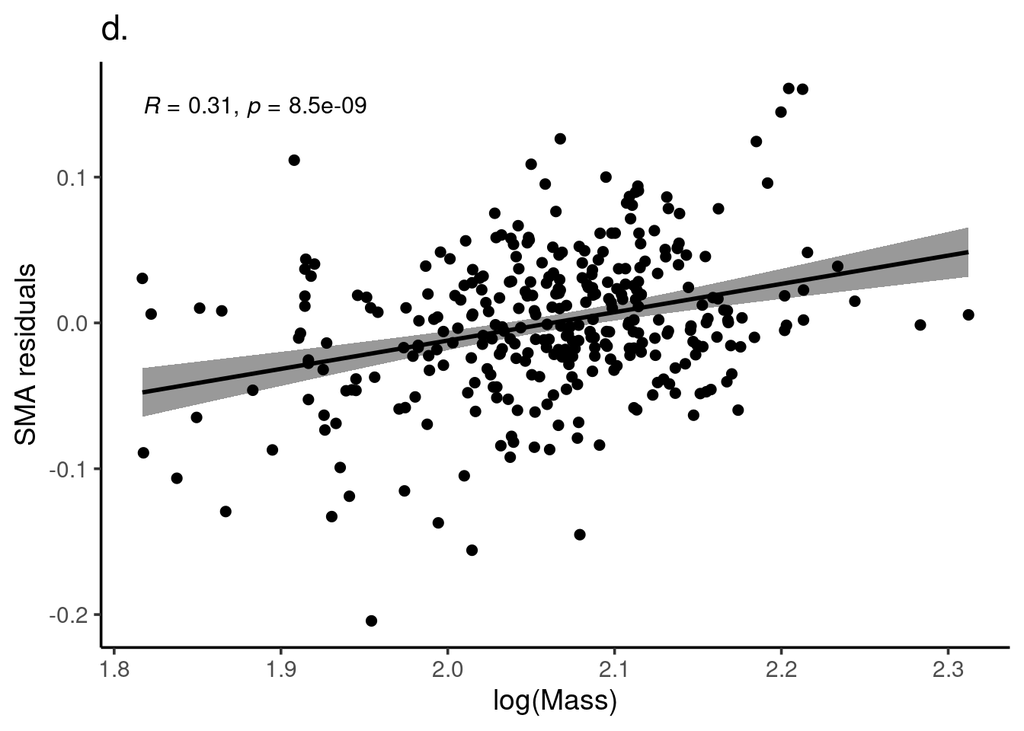

```r
p3 <- ggscatter(INDICES, x = "lpoids", y = "SMAresid",
    add = "reg.line", conf.int = TRUE, cor.coef = TRUE,
    cor.method = "pearson", xlab = "log(Mass)",
    ylab = "SMA residuals", cor.coef.size = 4) +
    ggtitle("d.") + theme_classic(base_size = 14)
p3
```

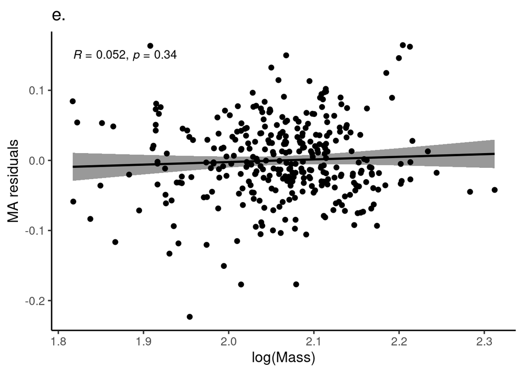

```r
p3a <- ggscatter(INDICES, x = "lpoids", y = "MAresid",
    add = "reg.line", conf.int = TRUE, cor.coef = TRUE,
    cor.method = "pearson", xlab = "log(Mass)",
    ylab = "MA residuals", cor.coef.size = 4) +
    ggtitle("e.") + theme_classic(base_size = 14)
p3a
```

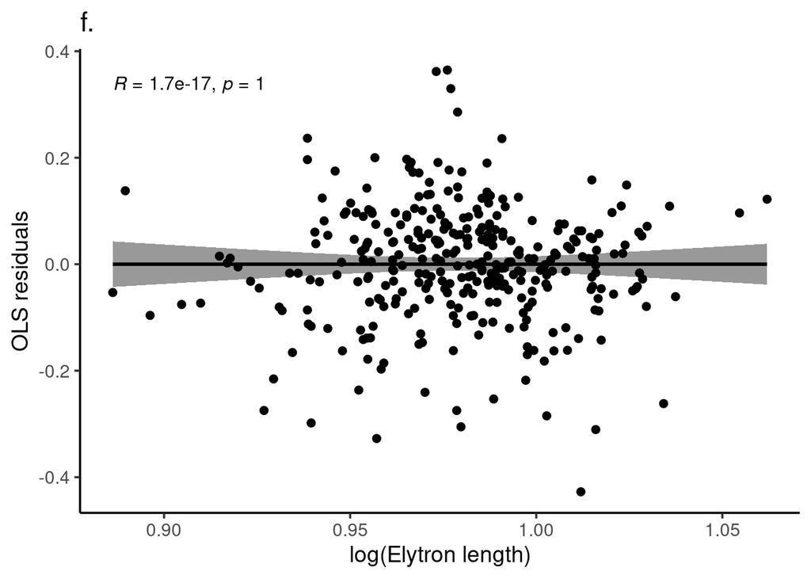

```r
p4 <- ggscatter(INDICES, x = "lmoyLong", y = "OLS",
    add = "reg.line", conf.int = TRUE, cor.coef = TRUE,
    cor.method = "pearson", xlab = "log(Elytron length)",
    ylab = "OLS residuals", cor.coef.size = 4) +
    ggtitle("f.") + theme_classic(base_size = 14)
p4
```

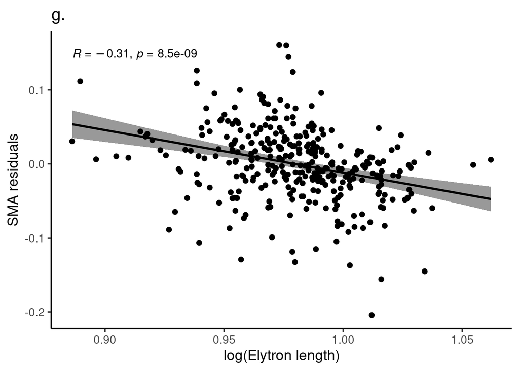

```r
p5 <- ggscatter(INDICES, x = "lmoyLong", y = "SMAresid",
    add = "reg.line", conf.int = TRUE, cor.coef = TRUE,
    cor.method = "pearson", xlab = "log(Elytron length)",
    ylab = "SMA residuals", cor.coef.size = 4) +
    ggtitle("g.") + theme_classic(base_size = 14)
p5
```

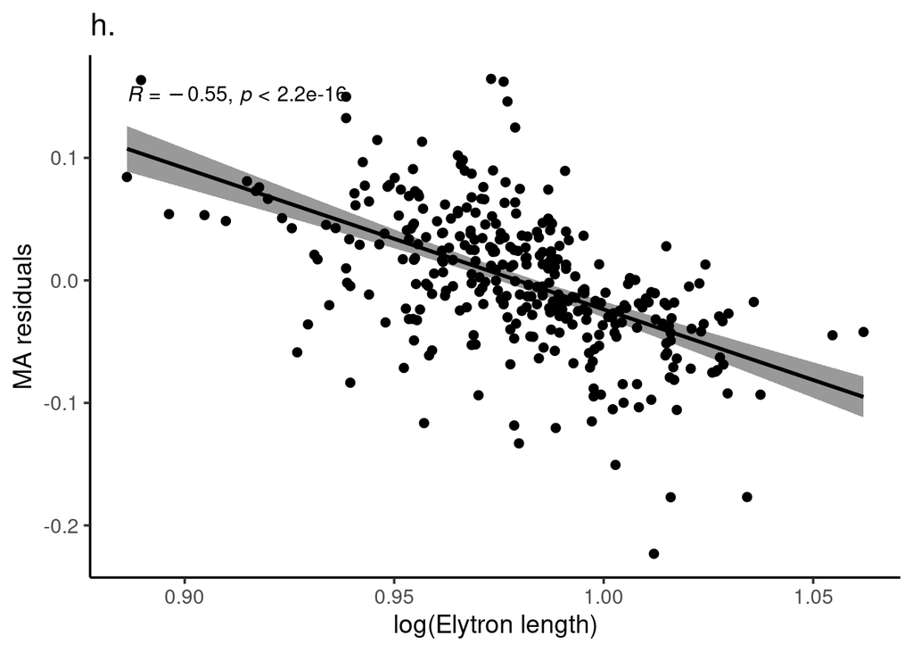

```r
p5a <- ggscatter(INDICES, x = "lmoyLong", y = "MAresid",
    add = "reg.line", conf.int = TRUE, cor.coef = TRUE,
    cor.method = "pearson", xlab = "log(Elytron length)",
    ylab = "MA residuals", cor.coef.size = 4) +
    ggtitle("h.") + theme_classic(base_size = 14)
p5a
```

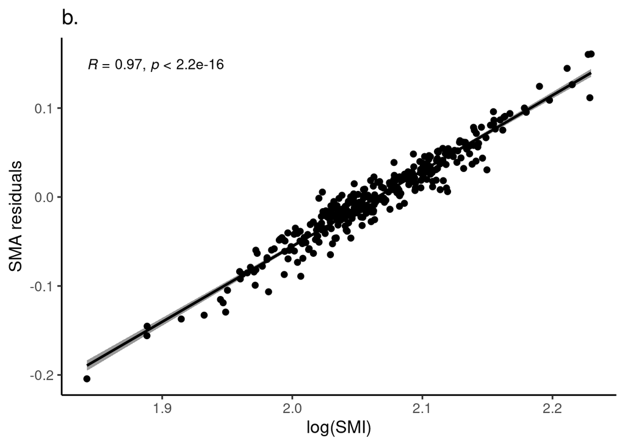

```r
INDICES$lSMAresid <- log10(INDICES$SMAresid +
    1)
INDICES$lMSL <- log10(INDICES$MSL)


p7a <- ggscatter(INDICES, x = "lMSL", y = "SMAresid",
    add = "reg.line", conf.int = TRUE, cor.coef = TRUE,
    cor.method = "pearson", xlab = "log(SMI)",
    ylab = "SMA residuals", cor.coef.size = 4) +
    ggtitle("b.") + theme_classic(base_size = 14)
p7a
```

```r
png("/home/mark/Dropbox/condition/apres JEB/FigureCorrelationPoidsTailleBCIa.png",
    width = 2970, height = 2970, res = 300)

pushViewport(viewport(layout = grid.layout(3,
    3)))
vplayout <- function(x, y) viewport(layout.pos.row = x,
    layout.pos.col = y)

print(p1, vp = vplayout(1, 1:2))
print(p7a, vp = vplayout(1, 3))
print(p2, vp = vplayout(2, 1))
print(p3, vp = vplayout(2, 2))
print(p3a, vp = vplayout(2, 3))
print(p4, vp = vplayout(3, 1))
print(p5, vp = vplayout(3, 2))
print(p5a, vp = vplayout(3, 3))

dev.off()
```